# EDA_GRP 10 updated

## 1. Importing necessary libraries

```python
#importing the necessary libraries
import pandas as pd
import numpy as np
import seaborn as sns #visualisation
import matplotlib.pyplot as plt #visualisation
%matplotlib inline
sns.set(color_codes=True)
from scipy import stats
import warnings
warnings.filterwarnings("ignore")
import inflection as inf #converts data into snakecase
from sklearn.preprocessing import LabelEncoder, OneHotEncoder
from sklearn.linear_model import LinearRegression
from matplotlib.ticker import FuncFormatter
import matplotlib.ticker as ticker
from sklearn.metrics import r2_score
from sklearn.metrics import mean_absolute_error
from sklearn.model_selection import train_test_split
from sklearn.preprocessing import StandardScaler
from sklearn.metrics import mean_squared_error
from sklearn.ensemble import RandomForestRegressor
from sklearn.svm import SVR
from sklearn.neural_network import MLPRegressor
import datetime as dt
from IPython.display import Image
import scipy.stats as stats
```

## 2. Importing Dataset¶

The encoding='ISO-8859-1' is used to handle special characters in the CSV files, because the default UTF-8 encoding failed

```python
#importing the dataset for the year 2010 and printing the head of the dataset
retail_2010 = pd.read_csv('/Users/prarthana/Downloads/Year_2009_2010.csv',encoding='ISO-8859-1')

# Display the first 10 rows of the data
print(retail_2010.head(10))
```

```
  Invoice StockCode                          Description  Quantity  \
0  489434     85048  15CM CHRISTMAS GLASS BALL 20 LIGHTS        12
1  489434    79323P                   PINK CHERRY LIGHTS        12
2  489434    79323W                  WHITE CHERRY LIGHTS        12
3  489434     22041         RECORD FRAME 7" SINGLE SIZE         48
4  489434     21232       STRAWBERRY CERAMIC TRINKET BOX        24
5  489434     22064           PINK DOUGHNUT TRINKET POT         24
6  489434     21871                  SAVE THE PLANET MUG        24
7  489434     21523   FANCY FONT HOME SWEET HOME DOORMAT        10
8  489435     22350                            CAT BOWL         12
9  489435     22349       DOG BOWL , CHASING BALL DESIGN        12

      InvoiceDate    Price  Customer ID         Country
0  12/1/2009 7:45 6.950000 13085.000000  United Kingdom
1  12/1/2009 7:45 6.750000 13085.000000  United Kingdom
2  12/1/2009 7:45 6.750000 13085.000000  United Kingdom
3  12/1/2009 7:45 2.100000 13085.000000  United Kingdom
4  12/1/2009 7:45 1.250000 13085.000000  United Kingdom
5  12/1/2009 7:45 1.650000 13085.000000  United Kingdom
6  12/1/2009 7:45 1.250000 13085.000000  United Kingdom
7  12/1/2009 7:45 5.950000 13085.000000  United Kingdom
8  12/1/2009 7:46 2.550000 13085.000000  United Kingdom
9  12/1/2009 7:46 3.750000 13085.000000  United Kingdom
```

```python
#importing the dataset for the year 2011 and printing the head of the dataset
retail_2011 = pd.read_csv('/Users/prarthana/Downloads/Year_2010_2011.csv',encoding='ISO-8859-1')
retail_2011.head(10)
```

|  | Invoice | StockCode | Description | Quantity | InvoiceDate | Price | Customer ID | Country |
| --- | --- | --- | --- | --- | --- | --- | --- | --- |
| 0 | 536365 | 85123A | WHITE HANGING HEART T-LIGHT HOLDER | 6 | 12/1/2010 8:26 | 2.550000 | 17850.000000 | United Kingdom |
| 1 | 536365 | 71053 | WHITE METAL LANTERN | 6 | 12/1/2010 8:26 | 3.390000 | 17850.000000 | United Kingdom |
| 2 | 536365 | 84406B | CREAM CUPID HEARTS COAT HANGER | 8 | 12/1/2010 8:26 | 2.750000 | 17850.000000 | United Kingdom |
| 3 | 536365 | 84029G | KNITTED UNION FLAG HOT WATER BOTTLE | 6 | 12/1/2010 8:26 | 3.390000 | 17850.000000 | United Kingdom |
| 4 | 536365 | 84029E | RED WOOLLY HOTTIE WHITE HEART. | 6 | 12/1/2010 8:26 | 3.390000 | 17850.000000 | United Kingdom |
| 5 | 536365 | 22752 | SET 7 BABUSHKA NESTING BOXES | 2 | 12/1/2010 8:26 | 7.650000 | 17850.000000 | United Kingdom |
| 6 | 536365 | 21730 | GLASS STAR FROSTED T-LIGHT HOLDER | 6 | 12/1/2010 8:26 | 4.250000 | 17850.000000 | United Kingdom |
| 7 | 536366 | 22633 | HAND WARMER UNION JACK | 6 | 12/1/2010 8:28 | 1.850000 | 17850.000000 | United Kingdom |
| 8 | 536366 | 22632 | HAND WARMER RED POLKA DOT | 6 | 12/1/2010 8:28 | 1.850000 | 17850.000000 | United Kingdom |
| 9 | 536368 | 22960 | JAM MAKING SET WITH JARS | 6 | 12/1/2010 8:34 | 4.250000 | 13047.000000 | United Kingdom |

```python
#Checking Dimensions of retail_2010 & retail_2011
print(retail_2010.shape)
print(retail_2011.shape)
```

```
(525461, 8)
(541910, 8)
```

## Combining datasets

By combining data from multiple years, you get a larger dataset covering a longer time period. This extended time frame can help in analyzing trends, seasonality, and other temporal patterns. Larger datasets generally provide more information, which can improve the performance and robustness of machine learning models. More data helps in better capturing the variability and patterns in the data.

```python
# Combine the datasets retail_2010 & retail_2011
retail_dataset = pd.concat([retail_2010, retail_2011])
print(retail_dataset.shape)
```

```
(1067371, 8)
```

```python
# Save the retail_dataset to a new CSV file
retail_dataset.to_csv('retail_2009-2011.csv', index=False)
retail_dataset.head()
```

|  | Invoice | StockCode | Description | Quantity | InvoiceDate | Price | Customer ID | Country |
| --- | --- | --- | --- | --- | --- | --- | --- | --- |
| 0 | 489434 | 85048 | 15CM CHRISTMAS GLASS BALL 20 LIGHTS | 12 | 12/1/2009 7:45 | 6.950000 | 13085.000000 | United Kingdom |
| 1 | 489434 | 79323P | PINK CHERRY LIGHTS | 12 | 12/1/2009 7:45 | 6.750000 | 13085.000000 | United Kingdom |
| 2 | 489434 | 79323W | WHITE CHERRY LIGHTS | 12 | 12/1/2009 7:45 | 6.750000 | 13085.000000 | United Kingdom |
| 3 | 489434 | 22041 | RECORD FRAME 7" SINGLE SIZE | 48 | 12/1/2009 7:45 | 2.100000 | 13085.000000 | United Kingdom |
| 4 | 489434 | 21232 | STRAWBERRY CERAMIC TRINKET BOX | 24 | 12/1/2009 7:45 | 1.250000 | 13085.000000 | United Kingdom |

## 3. CHECK THE DATATYPES

```python
retail_dataset.info()
```

```
<class 'pandas.core.frame.DataFrame'>
Index: 1067371 entries, 0 to 541909
Data columns (total 8 columns):
 #   Column       Non-Null Count    Dtype
---  ------       --------------    -----
 0   Invoice      1067371 non-null  object
 1   StockCode    1067371 non-null  object
 2   Description  1062989 non-null  object
 3   Quantity     1067371 non-null  int64
 4   InvoiceDate  1067371 non-null  object
 5   Price        1067371 non-null  float64
 6   Customer ID  824364 non-null   float64
 7   Country      1067371 non-null  object
dtypes: float64(2), int64(1), object(5)
memory usage: 73.3+ MB
```

```python
pd.set_option('display.float_format', '{:.2f}'.format)
retail_dataset.describe()
```

|  | Quantity | Price | Customer ID |
| --- | --- | --- | --- |
| count | 1067371.00 | 1067371.00 | 824364.00 |
| mean | 9.94 | 4.65 | 15324.64 |
| std | 172.71 | 123.55 | 1697.46 |
| min | -80995.00 | -53594.36 | 12346.00 |
| 25% | 1.00 | 1.25 | 13975.00 |
| 50% | 3.00 | 2.10 | 15255.00 |
| 75% | 10.00 | 4.15 | 16797.00 |
| max | 80995.00 | 38970.00 | 18287.00 |

### By looking at this, a few things stand out:

1. Negative Values: The presence of negative values in Quantity and Price suggests potential data entry errors or refund transactions.
2. Average Transaction Size: Most transactions involve a small number of items (1 to 10), indicating that customers typically make smaller purchases. This can inform inventory management and marketing strategies.
3. Wide Price Range: The dataset shows a broad range of item prices, reflecting a diverse product catalog. Analyzing sales performance across different price tiers can help identify which price points drive the most revenue.

#### 4. CHECK FOR DUPLICATED ROWS & DROP THEM

```python
# Checking for duplicated rows in the dataset
duplicates = retail_dataset.duplicated()
num_duplicates = duplicates.sum()
print(num_duplicates)
```

```
34335
```

```python
#removing duplicates
retail_dataset = retail_dataset.drop_duplicates()

#rechecking for duplicates in datasets
duplicates = retail_dataset.duplicated()
num_duplicates = duplicates.sum()
print(num_duplicates)
```

```
0
```

```python
#### 5. CHECK FOR NULL VALUES
```

```python
# Count the number of null values in each column
null_counts = retail_dataset.isnull().sum()

# Print the count of null values for each column
print(null_counts)
```

```
Invoice             0
StockCode           0
Description      4275
Quantity            0
InvoiceDate         0
Price               0
Customer ID    235151
Country             0
dtype: int64
```

## 6. RENAMING COLUMN HEADERS

For keeping all the column names consistent and simple for writing further codes, all the coliumn names have been converted into snakecase.

```python
#converting columns to snakecase
retail_dataset.columns = [inf.underscore(col) for col in retail_dataset.columns]
#to recheck the column names of the dataset
retail_dataset.head()
```

|  | invoice | stock_code | description | quantity | invoice_date | price | customer id | country |
| --- | --- | --- | --- | --- | --- | --- | --- | --- |
| 0 | 489434 | 85048 | 15CM CHRISTMAS GLASS BALL 20 LIGHTS | 12 | 12/1/2009 7:45 | 6.95 | 13085.00 | United Kingdom |
| 1 | 489434 | 79323P | PINK CHERRY LIGHTS | 12 | 12/1/2009 7:45 | 6.75 | 13085.00 | United Kingdom |
| 2 | 489434 | 79323W | WHITE CHERRY LIGHTS | 12 | 12/1/2009 7:45 | 6.75 | 13085.00 | United Kingdom |
| 3 | 489434 | 22041 | RECORD FRAME 7" SINGLE SIZE | 48 | 12/1/2009 7:45 | 2.10 | 13085.00 | United Kingdom |
| 4 | 489434 | 21232 | STRAWBERRY CERAMIC TRINKET BOX | 24 | 12/1/2009 7:45 | 1.25 | 13085.00 | United Kingdom |

```python
#converting the datatype of 'customer id' column
retail_dataset['customer id'] = retail_dataset['customer id'].astype('object')
print(retail_dataset.dtypes)
```

```
invoice          object
stock_code       object
description      object
quantity          int64
invoice_date     object
price           float64
customer id      object
country          object
dtype: object
```

#### 7. DROPPING NULL VALUES BASED ON SPECIFIED CONDITIONS

Upon going through the dataset, we have observed that several values in the 'price' and 'quantity' columns have values as '0' or 'negative'. Since this data is faulty and will not give us a correct analysis and results, rows which have wrongly entered data have been removed further

```python
# Remove rows where 'Price' <= 0 and 'Quantity' <= 0
retail_dataset= retail_dataset[(retail_dataset['price'] > 0) & (retail_dataset['quantity'] > 0)]
```

```python
# Remove rows where both 'Customer ID' and 'Description' are null
retail_dataset = retail_dataset.dropna(subset=['customer id', 'description'], how='all')

# Display the DataFrame after removing rows with both columns having null values
retail_dataset.head()
```

|  | invoice | stock_code | description | quantity | invoice_date | price | customer id | country |
| --- | --- | --- | --- | --- | --- | --- | --- | --- |
| 0 | 489434 | 85048 | 15CM CHRISTMAS GLASS BALL 20 LIGHTS | 12 | 12/1/2009 7:45 | 6.95 | 13085.00 | United Kingdom |
| 1 | 489434 | 79323P | PINK CHERRY LIGHTS | 12 | 12/1/2009 7:45 | 6.75 | 13085.00 | United Kingdom |
| 2 | 489434 | 79323W | WHITE CHERRY LIGHTS | 12 | 12/1/2009 7:45 | 6.75 | 13085.00 | United Kingdom |
| 3 | 489434 | 22041 | RECORD FRAME 7" SINGLE SIZE | 48 | 12/1/2009 7:45 | 2.10 | 13085.00 | United Kingdom |
| 4 | 489434 | 21232 | STRAWBERRY CERAMIC TRINKET BOX | 24 | 12/1/2009 7:45 | 1.25 | 13085.00 | United Kingdom |

```python
# Impute null values in 'Customer ID' column with 'Unavailable'
retail_dataset['customer id'] = retail_dataset['customer id'].fillna('Unavailable')
```

```python
# Count the number of null values in each column
null_count = retail_dataset.isnull().sum()

# Print the count of null values for each column
print(null_count)
```

```
invoice         0
stock_code      0
description     0
quantity        0
invoice_date    0
price           0
customer id     0
country         0
dtype: int64
```

```python
retail_dataset.shape
```

```
(1007914, 8)
```

## 8. VISUALIZING OUTLIERS

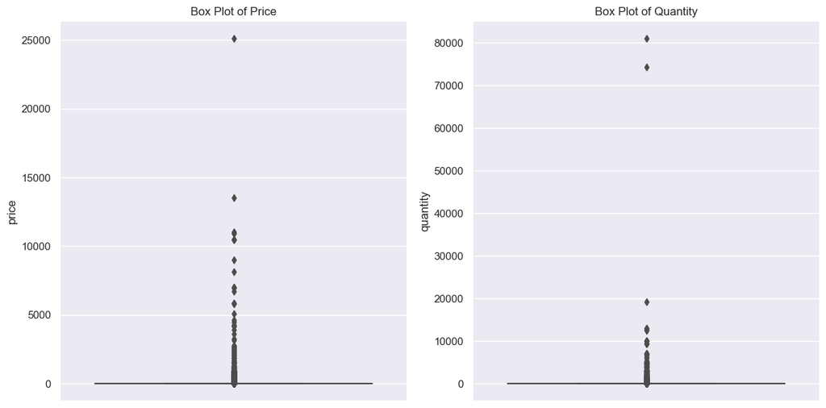

```python
# Set up the matplotlib figure
plt.figure(figsize=(12, 6))

# Plot box plot for 'Price' and 'Quantity'
plt.subplot(1, 2, 1)
sns.boxplot(y=retail_dataset['price'])
plt.title('Box Plot of Price')

plt.subplot(1, 2, 2)
sns.boxplot(y=retail_dataset['quantity'])
plt.title('Box Plot of Quantity')

# Display the plots
plt.tight_layout()
plt.show()
```

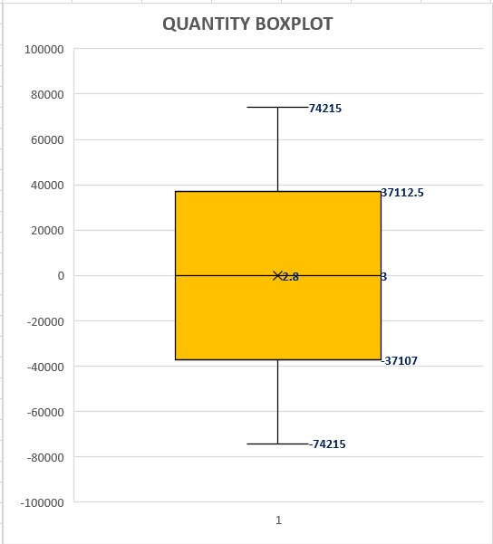

```python
Image(filename = r"/Users/prarthana/Downloads/WhatsApp Image 2024-08-16 at 01.31.22.jpeg")
```

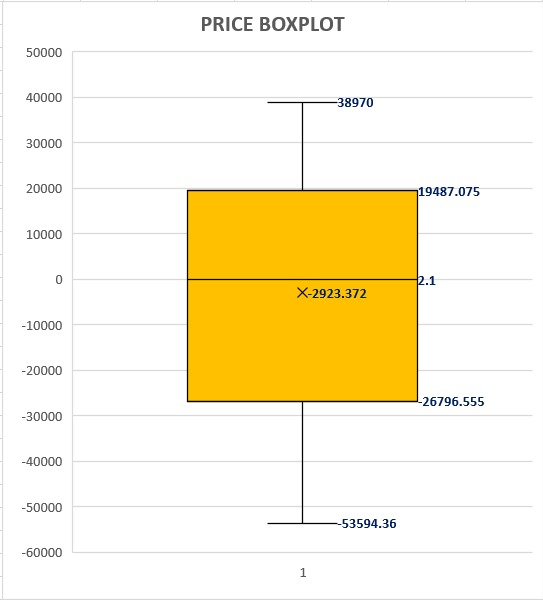

```python
Image(filename = r"/Users/prarthana/Downloads/WhatsApp Image 2024-08-16 at 01.31.36.jpeg")
```

## 9. Adding necessary columns for analysis

1. AOV
2. purchase frequency
3. customer value
4. categorical encoding for multivariate analysis (like heatmap)

```python
#creating an amount column
retail_dataset['amount'] = retail_dataset['quantity'] * retail_dataset['price']
retail_dataset.head()
```

|  | invoice | stock_code | description | quantity | invoice_date | price | customer id | country | amount |
| --- | --- | --- | --- | --- | --- | --- | --- | --- | --- |
| 0 | 489434 | 85048 | 15CM CHRISTMAS GLASS BALL 20 LIGHTS | 12 | 12/1/2009 7:45 | 6.95 | 13085.00 | United Kingdom | 83.40 |
| 1 | 489434 | 79323P | PINK CHERRY LIGHTS | 12 | 12/1/2009 7:45 | 6.75 | 13085.00 | United Kingdom | 81.00 |
| 2 | 489434 | 79323W | WHITE CHERRY LIGHTS | 12 | 12/1/2009 7:45 | 6.75 | 13085.00 | United Kingdom | 81.00 |
| 3 | 489434 | 22041 | RECORD FRAME 7" SINGLE SIZE | 48 | 12/1/2009 7:45 | 2.10 | 13085.00 | United Kingdom | 100.80 |
| 4 | 489434 | 21232 | STRAWBERRY CERAMIC TRINKET BOX | 24 | 12/1/2009 7:45 | 1.25 | 13085.00 | United Kingdom | 30.00 |

```python
retail_dataset['customer id'].value_counts()
```

```
customer id
Unavailable    228489
17841.0         12435
14911.0         11077
12748.0          6585
14606.0          6359
                ...
17102.0             1
17846.0             1
13366.0             1
17336.0             1
13128.0             1
Name: count, Length: 5879, dtype: int64
```

## 10. CREATING A CLTV DATASET

Since the original dataset does not have CLTV column or any other mertic that is essential for analysing CLTV, a new CLTV dataset has been created, containing all the essential metrics that have been calculated from the data provided in the original dataset.

```python
cltv = retail_dataset.groupby('customer id').agg({'invoice': lambda x: x.nunique(),
                                     'quantity' : lambda x: x.sum(),
                                     'amount': lambda x: x.sum()})
cltv.columns= ['total_transaction', 'total_unit', 'total_price' ]
print(cltv)
```

```
             total_transaction  total_unit  total_price
customer id
12346.0                     12       74285     77556.46
12347.0                      8        2967      4921.53
12348.0                      5        2714      2019.40
12349.0                      4        1624      4428.69
12350.0                      1         197       334.40
...                        ...         ...          ...
18284.0                      1         494       461.68
18285.0                      1         145       427.00
18286.0                      2         608      1296.43
18287.0                      7        3013      4182.99
Unavailable               3109      691197   3101829.75

[5879 rows x 3 columns]
```

```python
#converting cltv into a df (to ensure customer id is also a column in the df)
cltv = cltv.reset_index()
cltv.head()
```

|  | customer id | total_transaction | total_unit | total_price |
| --- | --- | --- | --- | --- |
| 0 | 12346.00 | 12 | 74285 | 77556.46 |
| 1 | 12347.00 | 8 | 2967 | 4921.53 |
| 2 | 12348.00 | 5 | 2714 | 2019.40 |
| 3 | 12349.00 | 4 | 1624 | 4428.69 |
| 4 | 12350.00 | 1 | 197 | 334.40 |

## 11. ADDING REQUIRED COLUMNS TO CLTV DATASET

1. average_order_value
2. purchase_frequency
3. customer_value

```python
#calculating average order value for each customer
cltv['average_order_value']= cltv['total_price'] / cltv['total_transaction']
cltv.head()
```

|  | customer id | total_transaction | total_unit | total_price | average_order_value |
| --- | --- | --- | --- | --- | --- |
| 0 | 12346.00 | 12 | 74285 | 77556.46 | 6463.04 |
| 1 | 12347.00 | 8 | 2967 | 4921.53 | 615.19 |
| 2 | 12348.00 | 5 | 2714 | 2019.40 | 403.88 |
| 3 | 12349.00 | 4 | 1624 | 4428.69 | 1107.17 |
| 4 | 12350.00 | 1 | 197 | 334.40 | 334.40 |

```python
#calculation of purchase frequency of each customer
cltv['purchase_frequency']= cltv['total_transaction'] / cltv.index.nunique()
cltv['purchase_frequency'] = cltv['purchase_frequency'].round(6)
pd.options.display.float_format = '{:.6f}'.format
cltv.head(10)
```

|  | customer id | total_transaction | total_unit | total_price | average_order_value | purchase_frequency |
| --- | --- | --- | --- | --- | --- | --- |
| 0 | 12346.000000 | 12 | 74285 | 77556.460000 | 6463.038333 | 0.002041 |
| 1 | 12347.000000 | 8 | 2967 | 4921.530000 | 615.191250 | 0.001361 |
| 2 | 12348.000000 | 5 | 2714 | 2019.400000 | 403.880000 | 0.000850 |
| 3 | 12349.000000 | 4 | 1624 | 4428.690000 | 1107.172500 | 0.000680 |
| 4 | 12350.000000 | 1 | 197 | 334.400000 | 334.400000 | 0.000170 |
| 5 | 12351.000000 | 1 | 261 | 300.930000 | 300.930000 | 0.000170 |
| 6 | 12352.000000 | 10 | 724 | 2849.840000 | 284.984000 | 0.001701 |
| 7 | 12353.000000 | 2 | 212 | 406.760000 | 203.380000 | 0.000340 |
| 8 | 12354.000000 | 1 | 530 | 1079.400000 | 1079.400000 | 0.000170 |
| 9 | 12355.000000 | 2 | 543 | 947.610000 | 473.805000 | 0.000340 |

```python
#calculation of average customer value for each customer
cltv['customer_value']= cltv['average_order_value'] * cltv['purchase_frequency']
print(cltv)
```

```
      customer id  total_transaction  total_unit    total_price  \
0    12346.000000                 12       74285   77556.460000
1    12347.000000                  8        2967    4921.530000
2    12348.000000                  5        2714    2019.400000
3    12349.000000                  4        1624    4428.690000
4    12350.000000                  1         197     334.400000
...           ...                ...         ...            ...
5874 18284.000000                  1         494     461.680000
5875 18285.000000                  1         145     427.000000
5876 18286.000000                  2         608    1296.430000
5877 18287.000000                  7        3013    4182.990000
5878  Unavailable               3109      691197 3101829.750000

      average_order_value  purchase_frequency  customer_value
0             6463.038333            0.002041       13.191061
1              615.191250            0.001361        0.837275
2              403.880000            0.000850        0.343298
3             1107.172500            0.000680        0.752877
4              334.400000            0.000170        0.056848
...                   ...                 ...             ...
5874           461.680000            0.000170        0.078486
5875           427.000000            0.000170        0.072590
5876           648.215000            0.000340        0.220393
5877           597.570000            0.001191        0.711706
5878           997.693712            0.528831      527.611363

[5879 rows x 7 columns]
```

## 11. Churn Rate

- Churn rate in business refers to the number of customers or subscribers that leave a provider in a given time period.
- Repeat Customer Rate is the proportion of your customers who have made at least two purchases during a certain time period.

```python
#Churn Rate = 1 - Repeat Rate
#Repeat Rate = The number of customers who make multiple purchases / Total customer count

repeat_rate = (cltv['total_transaction'] > 1).sum() / cltv.shape[0]
churn_rate = 1- repeat_rate
print(churn_rate)
print(repeat_rate)
```

```
0.27606735839428476
0.7239326416057152
```

- A high repeat rate suggests strong customer satisfaction and loyalty. It indicates that a significant majority of the customers find value in the products or services and are willing to return for repeat transactions. This is a positive sign for customer retention and the effectiveness of customer engagement strategies.
- A churn rate of 27.6% is relatively moderate. It suggests that while a substantial portion of customers are returning, there is also a significant number who are not. This indicates a need to address potential issues such as customer dissatisfaction, competition, or lack of effective follow-up and retention strategies. Reducing churn and improving the repeat rate could lead to increased customer lifetime value and overall business growth.

#### We are assuming that 10% profit from sales

```python
#computation of profit margin

cltv['profit_margin'] = cltv['total_price'] * 0.10
cltv.head()
```

|  | customer id | total_transaction | total_unit | total_price | average_order_value | purchase_frequency | customer_value | profit_margin |
| --- | --- | --- | --- | --- | --- | --- | --- | --- |
| 0 | 12346.000000 | 12 | 74285 | 77556.460000 | 6463.038333 | 0.002041 | 13.191061 | 7755.646000 |
| 1 | 12347.000000 | 8 | 2967 | 4921.530000 | 615.191250 | 0.001361 | 0.837275 | 492.153000 |
| 2 | 12348.000000 | 5 | 2714 | 2019.400000 | 403.880000 | 0.000850 | 0.343298 | 201.940000 |
| 3 | 12349.000000 | 4 | 1624 | 4428.690000 | 1107.172500 | 0.000680 | 0.752877 | 442.869000 |
| 4 | 12350.000000 | 1 | 197 | 334.400000 | 334.400000 | 0.000170 | 0.056848 | 33.440000 |

```python
#computing cltv of each customer
cltv['cltv'] = ( cltv['customer_value'] / churn_rate ) * cltv['profit_margin']
cltv.head()
```

|  | customer id | total_transaction | total_unit | total_price | average_order_value | purchase_frequency | customer_value | profit_margin | cltv |
| --- | --- | --- | --- | --- | --- | --- | --- | --- | --- |
| 0 | 12346.000000 | 12 | 74285 | 77556.460000 | 6463.038333 | 0.002041 | 13.191061 | 7755.646000 | 370580.578319 |
| 1 | 12347.000000 | 8 | 2967 | 4921.530000 | 615.191250 | 0.001361 | 0.837275 | 492.153000 | 1492.634076 |
| 2 | 12348.000000 | 5 | 2714 | 2019.400000 | 403.880000 | 0.000850 | 0.343298 | 201.940000 | 251.118417 |
| 3 | 12349.000000 | 4 | 1624 | 4428.690000 | 1107.172500 | 0.000680 | 0.752877 | 442.869000 | 1207.770520 |
| 4 | 12350.000000 | 1 | 197 | 334.400000 | 334.400000 | 0.000170 | 0.056848 | 33.440000 | 6.885990 |

```python
#checking details of the top 20 customers with highest cltv
cltv.sort_values(by='cltv', ascending=False).head(20)
```

|  | customer id | total_transaction | total_unit | total_price | average_order_value | purchase_frequency | customer_value | profit_margin | cltv |
| --- | --- | --- | --- | --- | --- | --- | --- | --- | --- |
| 5878 | Unavailable | 3109 | 691197 | 3101829.750000 | 997.693712 | 0.528831 | 527.611363 | 310182.975000 | 592812070.453881 |
| 5692 | 18102.000000 | 145 | 181645 | 580987.040000 | 4006.807172 | 0.024664 | 98.823892 | 58098.704000 | 20797605.659231 |
| 2277 | 14646.000000 | 151 | 367193 | 528602.520000 | 3500.678940 | 0.025685 | 89.914939 | 52860.252000 | 17216545.772616 |
| 1789 | 14156.000000 | 156 | 164325 | 313437.620000 | 2009.215513 | 0.026535 | 53.314534 | 31343.762000 | 6053153.342879 |
| 2538 | 14911.000000 | 398 | 147972 | 291420.810000 | 732.213090 | 0.067699 | 49.570094 | 29142.081000 | 5232692.858854 |
| 5050 | 17450.000000 | 51 | 83914 | 244784.250000 | 4799.691176 | 0.008675 | 41.637321 | 24478.425000 | 3691910.713920 |
| 1331 | 13694.000000 | 143 | 188201 | 195640.690000 | 1368.116713 | 0.024324 | 33.278071 | 19564.069000 | 2358317.476308 |
| 5109 | 17511.000000 | 60 | 117174 | 172132.870000 | 2868.881167 | 0.010206 | 29.279801 | 17213.287000 | 1825647.277049 |
| 4061 | 16446.000000 | 2 | 80997 | 168472.500000 | 84236.250000 | 0.000340 | 28.640325 | 16847.250000 | 1747800.675034 |
| 4295 | 16684.000000 | 55 | 104810 | 147142.770000 | 2675.323091 | 0.009355 | 25.027648 | 14714.277000 | 1333963.349897 |
| 68 | 12415.000000 | 28 | 91447 | 144458.370000 | 5159.227500 | 0.004763 | 24.573401 | 14445.837000 | 1285857.703045 |
| 2685 | 15061.000000 | 127 | 74280 | 126389.020000 | 995.189134 | 0.021602 | 21.498076 | 12638.902000 | 984223.825508 |
| 3647 | 16029.000000 | 107 | 54450 | 117763.620000 | 1100.594579 | 0.018200 | 20.030821 | 11776.362000 | 854466.115434 |
| 5540 | 17949.000000 | 118 | 60538 | 117314.080000 | 994.187119 | 0.020071 | 19.954330 | 11731.408000 | 847953.861513 |
| 2935 | 15311.000000 | 208 | 70149 | 114966.420000 | 552.723173 | 0.035380 | 19.555346 | 11496.642000 | 814369.405663 |
| 739 | 13089.000000 | 203 | 58932 | 113416.910000 | 558.703990 | 0.034530 | 19.292049 | 11341.691000 | 792576.338217 |
| 582 | 12931.000000 | 57 | 62906 | 92347.340000 | 1620.128772 | 0.009696 | 15.708769 | 9234.734000 | 525474.290331 |
| 1931 | 14298.000000 | 82 | 100272 | 91194.490000 | 1112.127927 | 0.013948 | 15.511960 | 9119.449000 | 512413.100492 |
| 3390 | 15769.000000 | 46 | 49068 | 88612.520000 | 1926.359130 | 0.007824 | 15.071834 | 8861.252000 | 483778.011658 |
| 0 | 12346.000000 | 12 | 74285 | 77556.460000 | 6463.038333 | 0.002041 | 13.191061 | 7755.646000 | 370580.578319 |

#### Outlier treatment has been omitted in our EDA analysis and CLTV predictive modeling for the following reasons:

- Outliers represent genuine high-value customer behavior, essential for accurate forecasting
- Retaining outliers helps identify top CLTV customers, enabling targeted strategies
- Excluding outliers could lead to missed revenue opportunities
- Advanced machine learning models effectively manage outliers, maintaining data integrity
- Outliers often signal distinct customer segments, crucial for personalized marketing
- Omitting outlier treatment ensures the model leverages all data, enhancing predictive accuracy and business insights

#### Formulae used for calculation of above metrics:

- CLTV = (Customer Value / Customer Churn Rate) * Profit Margin
- Customer Value = Average Order Value * Purchase Frequency
- Average Order Value = Total Price / Total Transaction
- Purchase Frequency = Total Transactions / Total Number of Customers
- Churn Rate = 1 - Proportion of Customers Who Make More Than One Purchase
- Profit Margin = Total Price * 0.10 (.10 may vary)

## 12. Performing Categorical Encoding on Columns

```python
#converitng the daatypes of 'country' and 'stock_code' column to perform categorical encoding
retail_dataset['country'] = retail_dataset['country'].astype('category')
retail_dataset['stock_code'] = retail_dataset['stock_code'].astype('string')
print(retail_dataset.info())
```

```
<class 'pandas.core.frame.DataFrame'>
Index: 1007914 entries, 0 to 541909
Data columns (total 9 columns):
 #   Column        Non-Null Count    Dtype
---  ------        --------------    -----
 0   invoice       1007914 non-null  object
 1   stock_code    1007914 non-null  string
 2   description   1007914 non-null  object
 3   quantity      1007914 non-null  int64
 4   invoice_date  1007914 non-null  object
 5   price         1007914 non-null  float64
 6   customer id   1007914 non-null  object
 7   country       1007914 non-null  category
 8   amount        1007914 non-null  float64
dtypes: category(1), float64(2), int64(1), object(4), string(1)
memory usage: 70.2+ MB
None
```

```python
#performing categorical encoding on country column for further analysis

# Initializing the LabelEncoder
label_encoder = LabelEncoder()

# Fitting and transforming the 'Country' column
retail_dataset['country_encoded'] = label_encoder.fit_transform(retail_dataset['country'])
retail_dataset['stock_code_encoded'] = label_encoder.fit_transform(retail_dataset['stock_code'])

# Displaying the first few rows of the updated dataset
print(retail_dataset.head())
```

```
  invoice stock_code                          description  quantity  \
0  489434      85048  15CM CHRISTMAS GLASS BALL 20 LIGHTS        12
1  489434     79323P                   PINK CHERRY LIGHTS        12
2  489434     79323W                  WHITE CHERRY LIGHTS        12
3  489434      22041         RECORD FRAME 7" SINGLE SIZE         48
4  489434      21232       STRAWBERRY CERAMIC TRINKET BOX        24

     invoice_date    price  customer id         country     amount  \
0  12/1/2009 7:45 6.950000 13085.000000  United Kingdom  83.400000
1  12/1/2009 7:45 6.750000 13085.000000  United Kingdom  81.000000
2  12/1/2009 7:45 6.750000 13085.000000  United Kingdom  81.000000
3  12/1/2009 7:45 2.100000 13085.000000  United Kingdom 100.800000
4  12/1/2009 7:45 1.250000 13085.000000  United Kingdom  30.000000

   country_encoded  stock_code_encoded
0               40                4217
1               40                3446
2               40                3448
3               40                1281
4               40                 632
```

```python
#rounding off price column to two decimal places
retail_dataset['price'] = retail_dataset['price'].apply(lambda x: round(x, 2))
```

```python
retail_dataset.head()
```

|  | invoice | stock_code | description | quantity | invoice_date | price | customer id | country | amount | country_encoded | stock_code_encoded |
| --- | --- | --- | --- | --- | --- | --- | --- | --- | --- | --- | --- |
| 0 | 489434 | 85048 | 15CM CHRISTMAS GLASS BALL 20 LIGHTS | 12 | 12/1/2009 7:45 | 6.950000 | 13085.000000 | United Kingdom | 83.400000 | 40 | 4217 |
| 1 | 489434 | 79323P | PINK CHERRY LIGHTS | 12 | 12/1/2009 7:45 | 6.750000 | 13085.000000 | United Kingdom | 81.000000 | 40 | 3446 |
| 2 | 489434 | 79323W | WHITE CHERRY LIGHTS | 12 | 12/1/2009 7:45 | 6.750000 | 13085.000000 | United Kingdom | 81.000000 | 40 | 3448 |
| 3 | 489434 | 22041 | RECORD FRAME 7" SINGLE SIZE | 48 | 12/1/2009 7:45 | 2.100000 | 13085.000000 | United Kingdom | 100.800000 | 40 | 1281 |
| 4 | 489434 | 21232 | STRAWBERRY CERAMIC TRINKET BOX | 24 | 12/1/2009 7:45 | 1.250000 | 13085.000000 | United Kingdom | 30.000000 | 40 | 632 |

```python
# Descriptive statistics
print(retail_dataset.describe())
```

```
            quantity          price         amount  country_encoded  \
count 1007914.000000 1007914.000000 1007914.000000   1007914.000000
mean       11.117168       4.074618      20.315854        38.127349
std       128.469962      50.431772     205.716027         6.848167
min         1.000000       0.000000       0.001000         0.000000
25%         1.000000       1.250000       4.130000        40.000000
50%         4.000000       2.100000      10.080000        40.000000
75%        12.000000       4.130000      17.700000        40.000000
max     80995.000000   25111.090000  168469.600000        42.000000

       stock_code_encoded
count      1007914.000000
mean          1924.305914
std           1177.995087
min              0.000000
25%           1105.000000
50%           1682.000000
75%           2495.000000
max           4916.000000
```

## 13. UNIVARIATE ANALYSIS OF DATA THROUGH VISUALIZATIONS

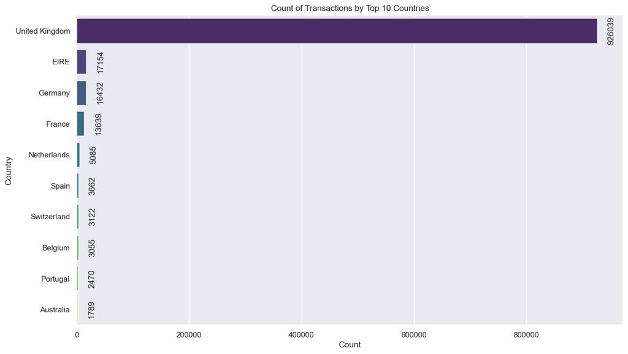

```python
#Graph showing Top 10 countries by the highest transaction count

# Get the top 10 countries by transaction count
top_10_countries = retail_dataset['country'].value_counts().head(10).index

# Filter the dataset to include only the top 10 countries
top_10_data = retail_dataset[retail_dataset['country'].isin(top_10_countries)]

# Create the count plot
plt.figure(figsize=(14, 8))
count_plot = sns.countplot(data=top_10_data, y='country', order=top_10_countries, palette='viridis')

# Add titles and labels
plt.title('Count of Transactions by Top 10 Countries')
plt.xlabel('Count')
plt.ylabel('Country')

# Add values on each bar
for p in count_plot.patches:
    count_plot.annotate(f'{int(p.get_width())}',
                        (p.get_width() + 100, p.get_y() + p.get_height() / 2),
                        ha='center', va='center',
                        xytext=(20, 0),
                        textcoords='offset points',
                        rotation=90)  # Rotate the text vertically

plt.show()
```

Observations and findings:

1. United Kingdom is observed to be the highest performing market, and this graph helps focus on regions with strong customer engagement
2. Countries with fewer transactions within the top 10 may represent opportunities for market expansion to boost CLTV.
3. Low-transaction countries in the top 10 might have higher churn risks, which can help the company re-evaluate their marketing and operational efforts in those areas

Given the large size of our dataset, approximately 1,000,000 rows, we employed random sampling to accurately visualize the distribution of specific variables. To thoroughly analyze data trends, we considered two sample sizes: one smaller and one larger.

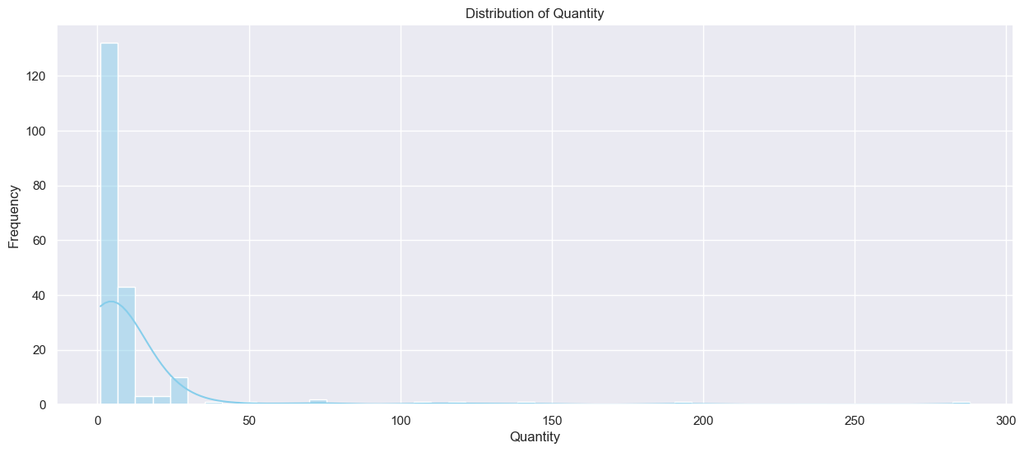

```python
#Graph to understand the range of quantity sold

# Subsampling the dataset to avoid overloading the memory
quantity_sample = retail_dataset['quantity'].sample(n=200, random_state=50)

# Plotting the histogram
plt.figure(figsize=(15, 6))
sns.histplot(quantity_sample, bins=50, kde=True, color='skyblue')
plt.title('Distribution of Quantity')
plt.xlabel('Quantity')
plt.ylabel('Frequency')
plt.show()
```

Observations a findings:

1. helps in identifying common order sizes, which informs inventory management and sales strategy
2. reveals any outliers or unusually large orders, which may need further investigation for potential bulk purchases, fradulant purchases or data entry errors
3. helps in predicting demand patterns, optimizing stock levels, and setting appropriate pricing strategies to enhance CLTV

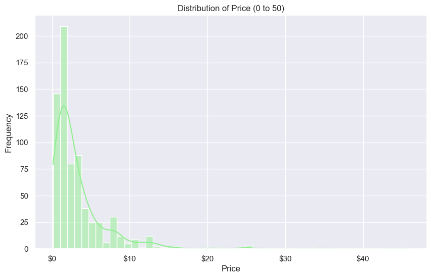

```python
#Graph to understand the range of price of products

# Function to add dollar sign to the price labels
def add_dollar(x, pos):
    return f'${x:,.0f}'

# Plotting the histogram
plt.figure(figsize=(10, 6))
sns.histplot(price_sample, bins=50, kde=True, color='lightgreen')

# Formatting the x-axis to include dollar signs
plt.gca().xaxis.set_major_formatter(FuncFormatter(add_dollar))

plt.title('Distribution of Price (0 to 50)')
plt.xlabel('Price')
plt.ylabel('Frequency')
plt.show()
```

Observations and findings::

1. The majority of products being low-cost (concentrated between 0-25) indicates that the majority of the inventory is low-cost, which could appeal to price-sensitive customers
2. Identifying the price distribution helps in exploring potential gaps where higher-priced products could be introduced to diversify the product range and increase revenue

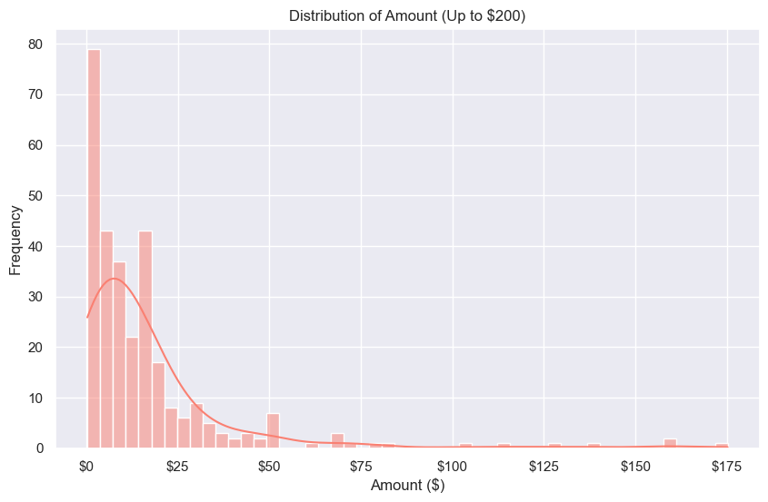

```python
# Graph showing distribution of Amount

# Function to add dollar sign to the amount labels
def add_dollar(x, pos):
    return f'${x:,.0f}'

# Subsampling the dataset and filtering amount to be less than or equal to 200
amount_sample = retail_dataset[retail_dataset['amount'] <= 200]['amount'].sample(n=300, random_state=40)

# Plotting the histogram
plt.figure(figsize=(10, 6))
sns.histplot(amount_sample, bins=50, kde=True, color='salmon')

# Formatting the x-axis to include dollar signs
plt.gca().xaxis.set_major_formatter(FuncFormatter(add_dollar))

plt.title('Distribution of Amount (Up to $200)')
plt.xlabel('Amount ($)')
plt.ylabel('Frequency')
plt.show()
```

Observations and findings:

1. Majority of transactions have lower amounts, suggesting that most customers tend to make smaller purchases. This could indicate a need to incentivize larger purchases through promotions or bundled offers to increase the average transaction value
2. Helps the company can identify opportunities to increase the average order value
3. The distribution is skewed with a long tail towards higher amounts, indicating that the occurence of high-value transactions are relatively rare. Targeted campaigns aimed at high-spending customers can be designed to further increase their spending or loyalty

### These univariate Graphs are to visualize the CLTV dataset

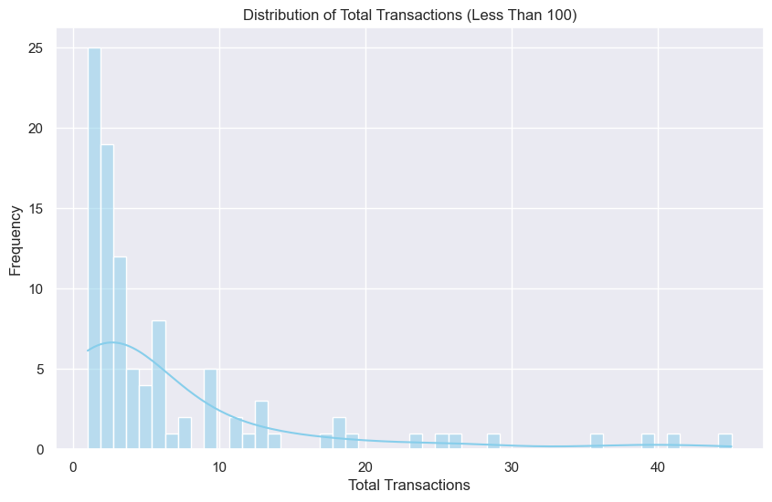

```python
#Graph showing the range of per transaction amount

# Subsampling the dataset and filtering total transactions to be less than 100
total_transaction_sample = cltv[cltv['total_transaction'] < 100]['total_transaction'].sample(n=100, random_state=50)

# Plotting the histogram
plt.figure(figsize=(10, 6))
sns.histplot(total_transaction_sample, bins=50, kde=True, color='skyblue')
plt.title('Distribution of Total Transactions (Less Than 100)')
plt.xlabel('Total Transactions')
plt.ylabel('Frequency')
plt.show()
```

Observations and findings:

1. this histogram reveals the range and concetration of the total transactions made by each surtomer, where the highest frequency of transactions are having lower frequency
2. The graph has a long tail towards the right, indicating very few customers have higher number of total transaction
3. targeted marketing strategies can help in influencing higher purchase frequency, thereby increasing lifetime value
4. analyzing total transactions and comparing it with the distribution of AOV helps in understanding which has a larger impact on CLTV

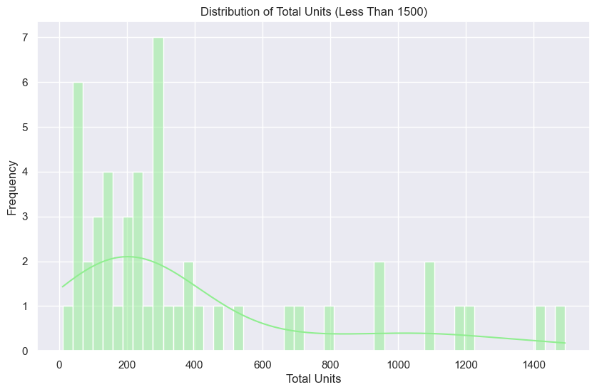

```python
#Graph showing the range of total units

# Subsampling the dataset and filtering total units to be less than 1500
total_unit_sample = cltv[cltv['total_unit'] < 1500]['total_unit'].sample(n=50, random_state=30)

# Plotting the histogram
plt.figure(figsize=(10, 6))
sns.histplot(total_unit_sample, bins=50, kde=True, color='lightgreen')
plt.title('Distribution of Total Units (Less Than 1500)')
plt.xlabel('Total Units')
plt.ylabel('Frequency')
plt.show()
```

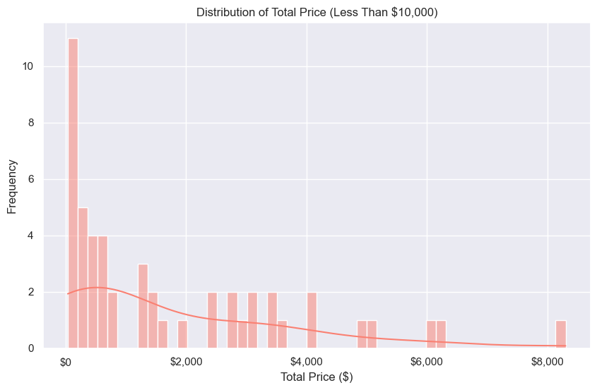

```python
#Graph showing range of product prices
# Function to add dollar sign to the price labels
def add_dollar(x, pos):
    return f'${x:,.0f}'

# Subsampling the dataset and filtering total price to be less than 10,000
total_price_sample = cltv[cltv['total_price'] < 10000]['total_price'].sample(n=50, random_state=30)

# Plotting the histogram
plt.figure(figsize=(10, 6))
sns.histplot(total_price_sample, bins=50, kde=True, color='salmon')

# Formatting the x-axis to include dollar signs
plt.gca().xaxis.set_major_formatter(FuncFormatter(add_dollar))

plt.title('Distribution of Total Price (Less Than $10,000)')
plt.xlabel('Total Price ($)')
plt.ylabel('Frequency')
plt.show()
```

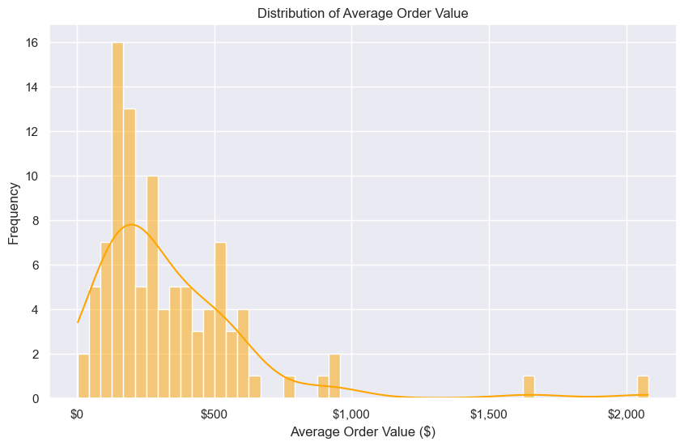

```python
#Graph showing range of AOV in the CLTV dataset
# Function to add dollar sign to the average order value labels
def add_dollar(x, pos):
    return f'${x:,.0f}'

# Subsampling the dataset to avoid overloading the memory
average_order_value_sample = cltv['average_order_value'].sample(n=100, random_state=80)

# Plotting the histogram
plt.figure(figsize=(10, 6))
sns.histplot(average_order_value_sample, bins=50, kde=True, color='orange')

# Formatting the x-axis to include dollar signs
plt.gca().xaxis.set_major_formatter(FuncFormatter(add_dollar))

plt.title('Distribution of Average Order Value')
plt.xlabel('Average Order Value ($)')
plt.ylabel('Frequency')
plt.show()
```

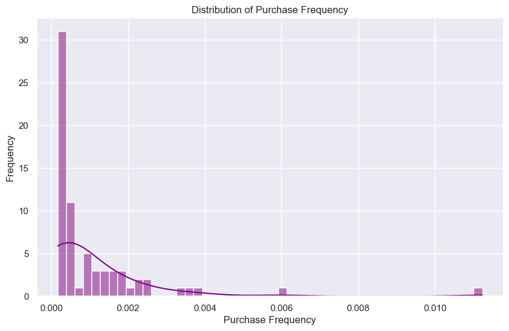

```python
#Graph showing range of purchase frequency of customers

# Subsampling the dataset to avoid overloading the memory
purchase_frequency_sample = cltv['purchase_frequency'].sample(n=70, random_state=50)

# Plotting the histogram
plt.figure(figsize=(10, 6))
sns.histplot(purchase_frequency_sample, bins=50, kde=True, color='purple')
plt.title('Distribution of Purchase Frequency')
plt.xlabel('Purchase Frequency')
plt.ylabel('Frequency')
plt.show()
```

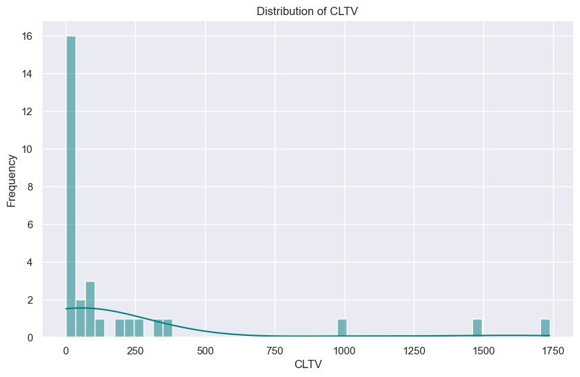

```python
#Graph showing the range of CLTV across customers

# Subsampling the dataset to avoid overloading the memory
cltv_sample = cltv['cltv'].sample(n=30, random_state=10)

# Plotting the histogram
plt.figure(figsize=(10, 6))
sns.histplot(cltv_sample, bins=50, kde=True, color='teal')
plt.title('Distribution of CLTV')
plt.xlabel('CLTV')
plt.ylabel('Frequency')
plt.show()
```

Observations and findings:

#### 13. BIVARIATE ANALYSIS OF DATA THROUGH VISUALIZATIONS

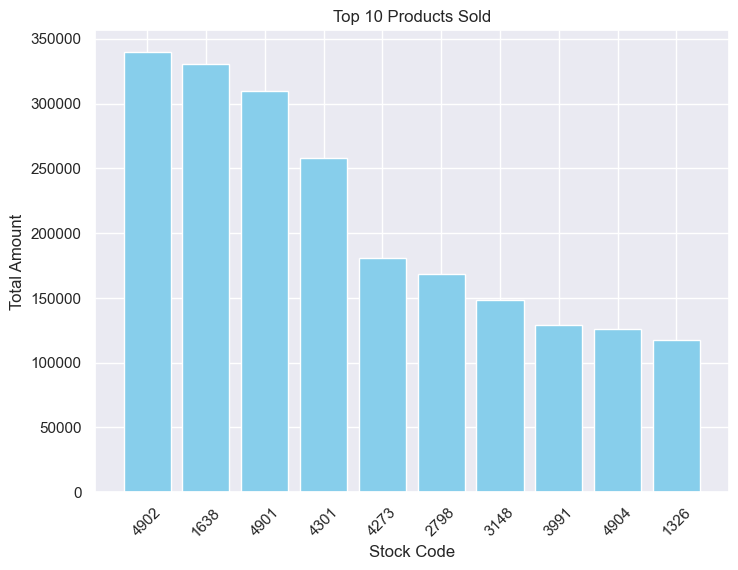

```python
#Graphs showing the Top and Bottom 10 products sold

# Calculate total amount for each stock_code_encoded
total_amount_by_stock = retail_dataset.groupby('stock_code_encoded')['amount'].sum().reset_index()

# Sort the aggregated data in descending order and select the top 10
top_10_stock = total_amount_by_stock.sort_values(by='amount', ascending=False).head(10)

# Sort the aggregated data in ascending order and select the bottom 10
bottom_10_stock = total_amount_by_stock.sort_values(by='amount', ascending=True).head(10)

# Create a figure with two subplots side by side
plt.figure(figsize=(18, 6))

# Plotting the bar graph for Top 10 Products Sold
plt.subplot(1, 2, 1)
plt.bar(top_10_stock['stock_code_encoded'].astype(str), top_10_stock['amount'], color='skyblue')
plt.title('Top 10 Products Sold')
plt.xlabel('Stock Code')
plt.ylabel('Total Amount')
plt.xticks(rotation=45)

# Display the plots
plt.show()
```

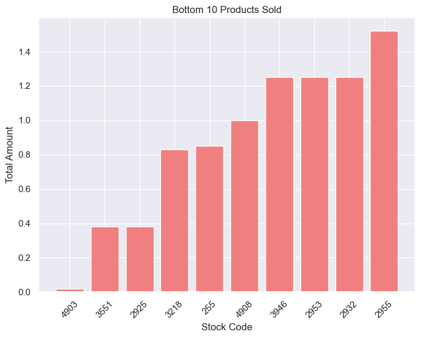

```python
# Create a figure with two subplots side by side
plt.figure(figsize=(18, 6))# Plotting the bar graph for Bottom 10 Products Sold
plt.subplot(1, 2, 2)
plt.bar(bottom_10_stock['stock_code_encoded'].astype(str), bottom_10_stock['amount'], color='lightcoral')
plt.title('Bottom 10 Products Sold')
plt.xlabel('Stock Code')
plt.ylabel('Total Amount')
plt.xticks(rotation=45)

# Display the plots
plt.show()
```

Observations and findings:

1. stock code 4902 and stock code 4903 is respectively the highest and lowest selling product
2. understanding product sales will help in improving inventory management and product performance
3. helps us in predicting profitability and understanding customer buying behaviour
4. Will facilitate decisions related to product-line expansion, discontinuation, improved pricing strategies and promotional campaigns, and also help in understanding the potential gaps in the product range and offerings

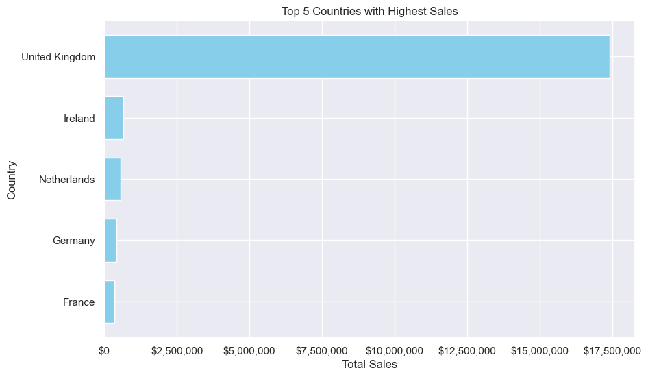

```python
#Graph Showing Top 5 Countries with Highest Sales Amount

# Rename 'EIRE' to 'Ireland'
retail_dataset['country'] = retail_dataset['country'].replace('EIRE', 'Ireland')

# Calculate total amount for each country
total_amount_by_country = retail_dataset.groupby('country')['amount'].sum().reset_index()

# Sort the aggregated data in descending order and select the top 5 distinct countries
top_5_distinct_countries = total_amount_by_country.sort_values(by='amount', ascending=False).head(5)

# Define a formatter function to format the amounts
def currency_formatter(x, pos):
    return f'${x:,.0f}'

# Plotting the bar graph
plt.figure(figsize=(10, 6))  # Adjust plot size to be smaller

# Plot horizontal bars with reduced bar height
bars = plt.barh(
    top_5_distinct_countries['country'],
    top_5_distinct_countries['amount'],
    color='skyblue',
    height=0.7  # Reduce bar height to make bars thinner
)

plt.title('Top 5 Countries with Highest Sales')
plt.xlabel('Total Sales')
plt.ylabel('Country')
plt.gca().invert_yaxis()  # Invert y-axis to show the highest at the top

# Apply the formatter to the x-axis
plt.gca().xaxis.set_major_formatter(FuncFormatter(currency_formatter))

plt.show()
```

Observations and findings:

1. from this graph, we can see that UK is the counntry with highest level of operations and sales followed by the other countries which have substantial differences in the sales amount
2. Analyzing top-performing countries/markets will help us in market prioritization, performance benchmarking and revenue optimization
3. Analyzing underperforming markets helps the company determine if improvements are possible or if operations should be scaled back, redirecting resources to more profitable markets

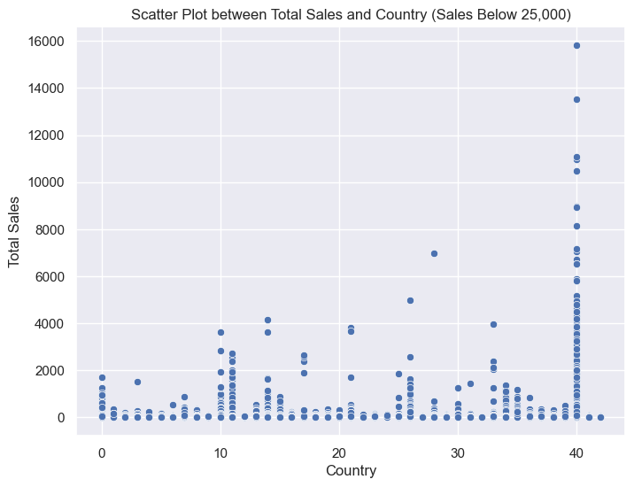

```python
# Scatter plot showing the relationship between Total Sales & Country

# Filtering the dataset for total sales below 25,000
filtered_retail_dataset = retail_dataset[retail_dataset['amount'] < 25000]

# Plotting the scatter plot
plt.figure(figsize=(8, 6))
sns.scatterplot(data=filtered_retail_dataset, x='country_encoded', y='amount')
plt.title('Scatter Plot between Total Sales and Country (Sales Below 25,000)')
plt.xlabel('Country')
plt.ylabel('Total Sales')
plt.show()
```

Observations and findings:

1. UK (country code-40) is observed to have the highest sales values, indicating that a higher ratio of the operational and marketing resources needs to be diverted towards their largest market to enhance customer retention and promote the growth of CLTV
2. Understanding the distribution of total sales by country will help in product localisation, improved sales forecasting and provides the guide for formulating effective expansion strategies

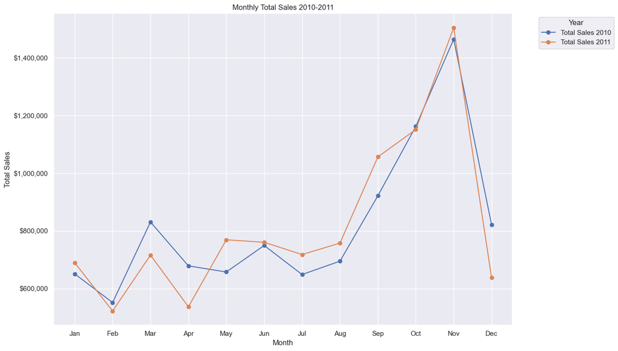

```python
#Graph showing the monthly sale trend for two years (2010-2011)

# Ensure invoice_date is in datetime format
retail_dataset['invoice_date'] = pd.to_datetime(retail_dataset['invoice_date'])

# Extract year and month from invoice_date
retail_dataset['year'] = retail_dataset['invoice_date'].dt.year
retail_dataset['month'] = retail_dataset['invoice_date'].dt.month

# Filter out data for the year 2009
retail_dataset = retail_dataset[retail_dataset['year'] != 2009]

# Aggregate total sales by year and month
total_sales = retail_dataset.groupby(['year', 'month'])['amount'].sum().reset_index()

# Prepare for plotting
plt.figure(figsize=(14, 8))

# Plot total sales for each year
for year in total_sales['year'].unique():
    year_sales = total_sales[total_sales['year'] == year]
    plt.plot(year_sales['month'], year_sales['amount'], marker='o', label=f'Total Sales {year}')

# Title and labels
plt.title('Monthly Total Sales 2010-2011')
plt.xlabel('Month')
plt.ylabel('Total Sales')

# X-axis ticks and labels
plt.xticks(ticks=range(1, 13), labels=['Jan', 'Feb', 'Mar', 'Apr', 'May', 'Jun', 'Jul', 'Aug', 'Sep', 'Oct', 'Nov', 'Dec'])

# Format y-axis labels to show as currency
def currency_formatter(x, pos):
    return f'${x:,.0f}'

plt.gca().yaxis.set_major_formatter(FuncFormatter(currency_formatter))

# Add legend
plt.legend(title='Year', bbox_to_anchor=(1.05, 1), loc='upper left')

plt.grid(True)

plt.tight_layout()  # Adjust layout to make room for the legend
plt.show()
```

Observations and findings:

1. The spike in sales during November highlights a key period for maximizing CLTV through targeted promotions, discounts, and marketing efforts
2. The low sales in February suggest an opportunity to introduce special offers or loyalty programs to reduce customer churn and maintain steady revenue during slower months
3. The relatively stable sales pattern across both years can be used to predict future trends, helping the company optimize inventory, marketing spend, and resource allocation to improve overall CLTV and reduce acquisition costs

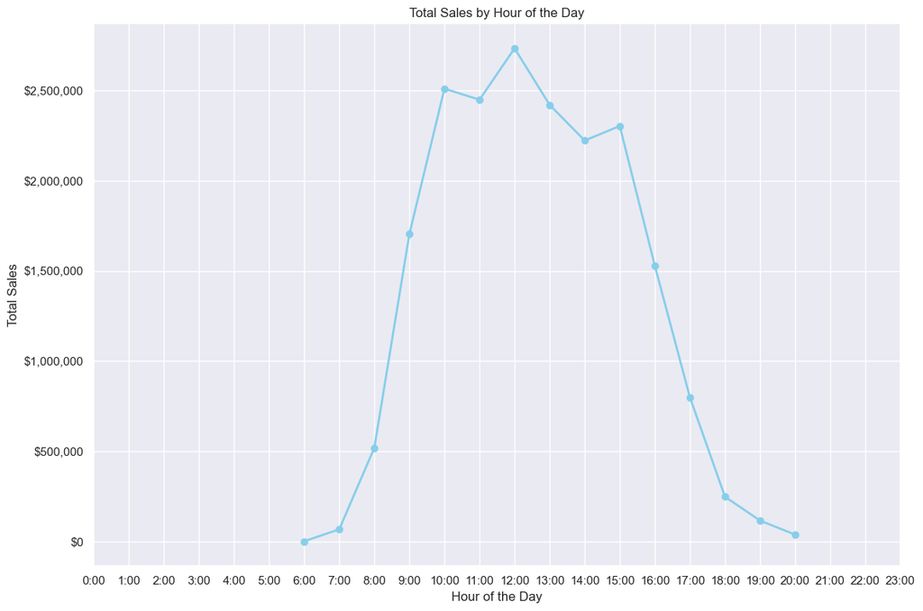

```python
#Graph showing Total Sales by the Time of Day

# Ensure invoice_date is in datetime format
retail_dataset['invoice_date'] = pd.to_datetime(retail_dataset['invoice_date'])

# Extract hour from invoice_date
retail_dataset['hour'] = retail_dataset['invoice_date'].dt.hour

# Aggregate total amount by hour
hourly_sales = retail_dataset.groupby('hour')['amount'].sum().reset_index()

# Prepare for plotting
plt.figure(figsize=(12, 8))

# Plot total sales by hour
plt.plot(hourly_sales['hour'], hourly_sales['amount'], marker='o', color='skyblue', linestyle='-', linewidth=2)

# Title and labels
plt.title('Total Sales by Hour of the Day')
plt.xlabel('Hour of the Day')
plt.ylabel('Total Sales')

# X-axis ticks and labels
plt.xticks(ticks=range(0, 24), labels=[f'{h}:00' for h in range(0, 24)])

# Format y-axis labels to show as currency
def currency_formatter(x, pos):
    return f'${x:,.0f}'

plt.gca().yaxis.set_major_formatter(FuncFormatter(currency_formatter))

plt.grid(True)

plt.tight_layout()
plt.show()
```

Observations and findings:

1. as observed from the graph, peak hours of the day with highest number of sales is 10 am to 3pm, suggesting that having higher staff during these hours can help in giving customers a better shopping experience
2. effective inventory management and reduction in waiting time can help increase customer engagement, thereby leading to revenue maximization
3. marketing strategies should be designed such that they align with the peak sales period to increase overall sales

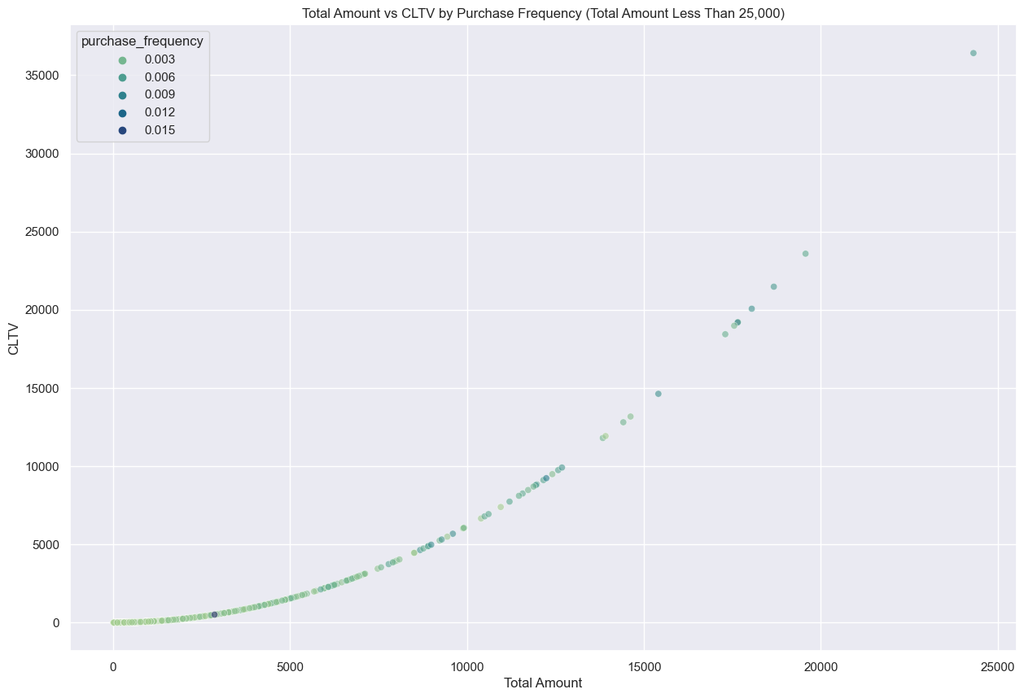

```python
#Graph showing relationship between Total Price of Products & CLTV with respect to Purchase Frequency

# Filtering the dataset for total amount less than 25,000
filtered_cltv = cltv[cltv['total_price'] < 25000]

# Subsampling the filtered dataset to avoid overloading the memory
cltv_sample = filtered_cltv.sample(n=1000, random_state=50)

# Plotting Total Price vs CLTV colored by Purchase Frequency
plt.figure(figsize=(15, 10))
sns.scatterplot(x='total_price', y='cltv', hue='purchase_frequency', data=cltv_sample, alpha=0.6, palette='crest')
plt.title('Total Amount vs CLTV by Purchase Frequency (Total Amount Less Than 25,000)')
plt.xlabel('Total Amount')
plt.ylabel('CLTV')
plt.show()
```

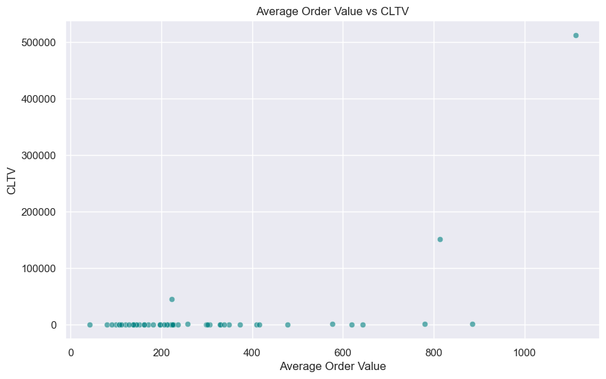

```python
#Graph showing relationship between AOV and CLTV of customers

# Subsampling the dataset to avoid overloading the memory
cltv_sample = cltv.sample(n=50, random_state=10)

# Plotting Average Order Value vs CLTV
plt.figure(figsize=(10, 6))
sns.scatterplot(x='average_order_value', y='cltv', data=cltv_sample, alpha=0.6, color='teal')
plt.title('Average Order Value vs CLTV')
plt.xlabel('Average Order Value')
plt.ylabel('CLTV')
plt.show()
```

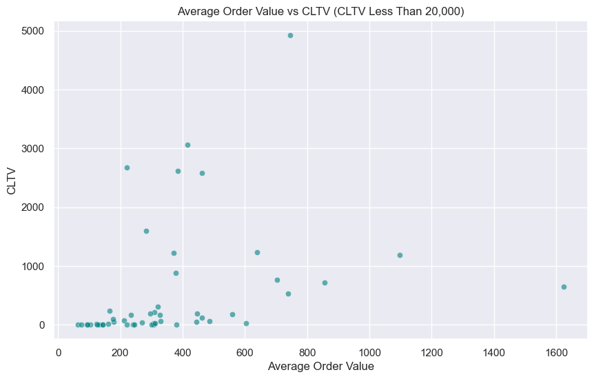

```python
# Filtering the dataset for CLTV less than 20,000
filtered_cltv = cltv[cltv['cltv'] < 20000]

# Subsampling the filtered dataset to avoid overloading the memory
cltv_sample = filtered_cltv.sample(n=50, random_state=10)

# Plotting Average Order Value vs CLTV
plt.figure(figsize=(10, 6))
sns.scatterplot(x='average_order_value', y='cltv', data=cltv_sample, alpha=0.6, color='teal')
plt.title('Average Order Value vs CLTV (CLTV Less Than 20,000)')
plt.xlabel('Average Order Value')
plt.ylabel('CLTV')
plt.show()
```

Observations and findings:

### 13. MULTIVARIATE ANALYSIS OF DATA THROUGH VISUALIZATIONS

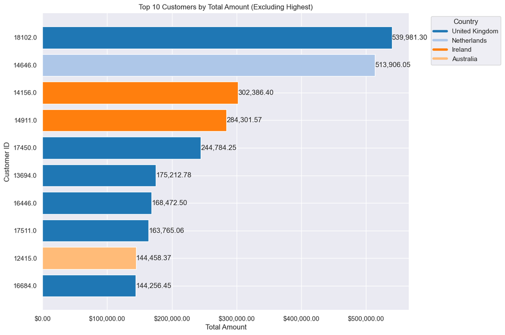

```python
# Graph showing Top 10 Customers by their Total Amount of Purchase & their Country

# Create a mapping dictionary from country_encoded to country names
country_mapping = retail_dataset[['country_encoded', 'country']].drop_duplicates().set_index('country_encoded')['country'].to_dict()

# Define a criterion for excluding unavailable customer IDs
available_customers_dataset = retail_dataset[retail_dataset['country'] != 'Unavailable']

# Aggregate total amount by customer ID and country_encoded
customer_amount = available_customers_dataset.groupby(['customer id', 'country_encoded'])['amount'].sum().reset_index()

# Sort by total amount and select the top 10
top_customers = customer_amount.sort_values(by='amount', ascending=False)

# Exclude the highest value
top_customers = top_customers.iloc[1:11]  # Skip the first row and take the next 10 to avoid showing unavailable customer_id

# Map country_encoded to actual country names
top_customers['country'] = top_customers['country_encoded'].map(country_mapping)

# Create a color palette for countries
palette = sns.color_palette("tab20", len(top_customers['country'].unique()))
country_colors = {country: palette[i] for i, country in enumerate(top_customers['country'].unique())}

# Plotting the bar graph
plt.figure(figsize=(12, 8))
bars = plt.barh(
    top_customers['customer id'].astype(str),  # Remove country names from the label
    top_customers['amount'],
    color=[country_colors[country] for country in top_customers['country']]
)

# Add labels on bars
for bar in bars:
    plt.text(bar.get_width() + 1, bar.get_y() + bar.get_height()/2, f'{bar.get_width():,.2f}', va='center')

plt.title('Top 10 Customers by Total Amount (Excluding Highest)')
plt.xlabel('Total Amount')
plt.ylabel('Customer ID')

# Format x-axis labels for better readability
plt.gca().xaxis.set_major_formatter(ticker.FuncFormatter(lambda x, _: f'${x:,.2f}'))

plt.gca().invert_yaxis()  # Invert y-axis to show the highest at the top

# Add a legend
plt.legend(handles=[plt.Line2D([0], [0], color=color, lw=4) for country, color in country_colors.items()],
           labels=[country for country in country_colors.keys()],
           title='Country',
           bbox_to_anchor=(1.05, 1),
           loc='upper left')

plt.tight_layout()  # Adjust layout to make room for the legend
plt.show()
```

Observations and findings:

1. Out of the top 10 customers, majority of the customers are based in UK, the company's largest target market
2. Netherlands, Ireland and Australia aslo have high-value customers, which indicates that there is scope for growth in these countries and attracting more customers
3. It helps identify loyal customers, tailor personalized offers, and design strategies for revenue concentration and customer segmentation, ultimately boosting customer retention and increasing sales

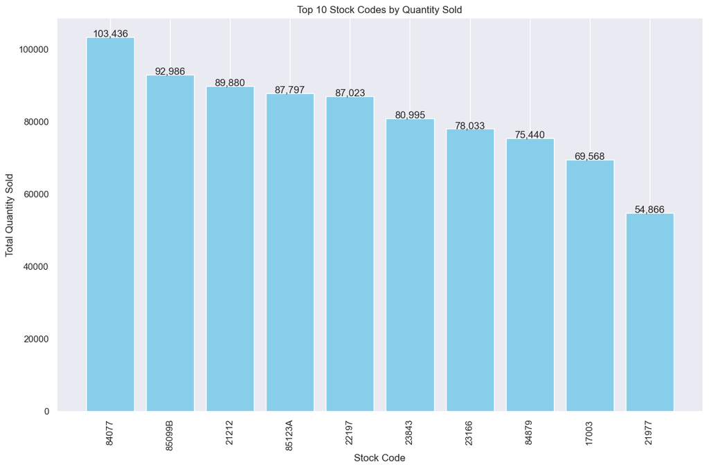

```
   stock_code  quantity                         description         country
0       84077    103436   WORLD WAR 2 GLIDERS ASSTD DESIGNS  United Kingdom
1      85099B     92986         JUMBO BAG RED WHITE SPOTTY   United Kingdom
2      85099B     92986            RED RETROSPOT JUMBO BAG   United Kingdom
3      85099B     92986             JUMBO BAG RED RETROSPOT  United Kingdom
4       21212     89880    PACK OF 72 RETRO SPOT CAKE CASES  United Kingdom
5       21212     89880     PACK OF 72 RETROSPOT CAKE CASES  United Kingdom
6      85123A     87797  WHITE HANGING HEART T-LIGHT HOLDER  United Kingdom
7      85123A     87797  CREAM HANGING HEART T-LIGHT HOLDER  United Kingdom
8       22197     87023             POPCORN HOLDER , SMALL   United Kingdom
9       22197     87023                SMALL POPCORN HOLDER  United Kingdom
10      22197     87023                      POPCORN HOLDER  United Kingdom
11      23843     80995         PAPER CRAFT , LITTLE BIRDIE  United Kingdom
12      23166     78033      MEDIUM CERAMIC TOP STORAGE JAR  United Kingdom
13      84879     75440       ASSORTED COLOUR BIRD ORNAMENT  United Kingdom
14      17003     69568                 BROCADE RING PURSE   United Kingdom
15      21977     54866  PACK OF 60 PINK PAISLEY CAKE CASES  United Kingdom
```

```python
#Graph showing the realtionship between Top 10 Products by Sales & Qty of each sold

# Aggregate total quantity by stock code and country
quantity_by_stock_country = retail_dataset.groupby(['stock_code', 'country_encoded'])['quantity'].sum().reset_index()

# Identify the country with the highest quantity sold for each stock code
top_country_per_stock = quantity_by_stock_country.loc[quantity_by_stock_country.groupby('stock_code')['quantity'].idxmax()]

# Create a mapping dictionary from country_encoded to country names
country_mapping = retail_dataset[['country_encoded', 'country']].drop_duplicates().set_index('country_encoded')['country'].to_dict()

# Map country_encoded to actual country names
top_country_per_stock['country'] = top_country_per_stock['country_encoded'].map(country_mapping)

# Aggregate total quantity by stock code
stock_code_quantity = retail_dataset.groupby('stock_code')['quantity'].sum().reset_index()

# Sort by quantity in descending order and select the top stock codes
top_stock_codes = stock_code_quantity.sort_values(by='quantity', ascending=False).head(10)

# Plotting the bar graph
plt.figure(figsize=(12, 8))
bars = plt.bar(top_stock_codes['stock_code'], top_stock_codes['quantity'], color='skyblue')

# Add labels on bars
for bar in bars:
    plt.text(bar.get_x() + bar.get_width()/2, bar.get_height() + 50, f'{bar.get_height():,.0f}', ha='center')

plt.title('Top 10 Stock Codes by Quantity Sold')
plt.xlabel('Stock Code')
plt.ylabel('Total Quantity Sold')

plt.xticks(rotation=90)
plt.grid(axis='y')

plt.tight_layout()
plt.show()

# Create a dataset for the top stock codes with descriptions and top-selling country
# Assuming `stock_code_descriptions` is a DataFrame with stock_code and description columns
stock_code_descriptions = retail_dataset[['stock_code', 'description']].drop_duplicates().dropna()

# Merge the descriptions with the top stock codes
top_stock_codes_with_desc = top_stock_codes.merge(stock_code_descriptions, on='stock_code', how='left')

# Map the top country per stock code to the top stock codes
top_stock_codes_with_desc = top_stock_codes_with_desc.merge(
    top_country_per_stock[['stock_code', 'country']],
    on='stock_code',
    how='left'
)

print(top_stock_codes_with_desc)
```

Observations and findings:

1. stock code 84077 is the highest sold product with 1,03,436 units being sold between 2010-2011
2. Stationery, Kitchen and Home Decor, Fashion - these three categories of products are seen to be the highest selling ones, hilighting the potential for expansion of these product categories
3. Helps in better in inventory management, demand forecasting, and supply chain efficiency. It also provides insights into customer preferences, guiding targeted marketing strategies

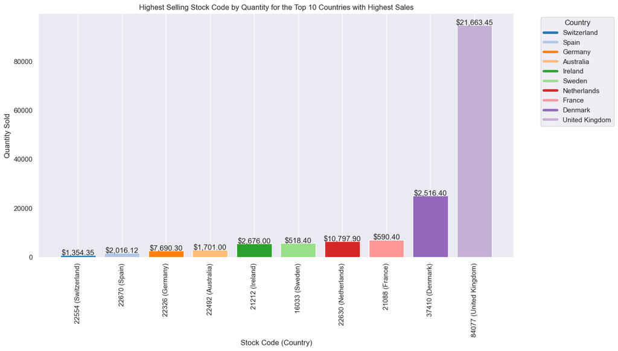

```python
#Graph showing Top Selling Products by Qty in Countries with Highest Sales

# Aggregate total quantity and total sales by stock code and country
stock_code_country_stats = retail_dataset.groupby(['stock_code', 'country_encoded'])[['quantity', 'amount']].sum().reset_index()

# Identify the stock code with the highest quantity sold for each country
top_stock_per_country = stock_code_country_stats.loc[stock_code_country_stats.groupby('country_encoded')['quantity'].idxmax()]

# Aggregate total sales by country to identify the top 10 countries
country_sales = retail_dataset.groupby('country_encoded')['amount'].sum().reset_index()
top_countries = country_sales.sort_values(by='amount', ascending=False).head(10)

# Filter the top stock codes to only include the top 10 countries
top_stock_per_country_filtered = top_stock_per_country[top_stock_per_country['country_encoded'].isin(top_countries['country_encoded'])]

# Create a mapping dictionary from country_encoded to country names
country_mapping = retail_dataset[['country_encoded', 'country']].drop_duplicates().set_index('country_encoded')['country'].to_dict()

# Map country_encoded to actual country names
top_stock_per_country_filtered['country'] = top_stock_per_country_filtered['country_encoded'].map(country_mapping)

# Sort the data by quantity in ascending order
top_stock_per_country_filtered = top_stock_per_country_filtered.sort_values(by='quantity')

# Define a color palette for countries
unique_countries = top_stock_per_country_filtered['country'].unique()
palette = sns.color_palette("tab20", len(unique_countries))
country_colors = {country: palette[i] for i, country in enumerate(unique_countries)}

# Plotting the bar graph
plt.figure(figsize=(14, 8))
bars = plt.bar(
    top_stock_per_country_filtered['stock_code'] + ' (' + top_stock_per_country_filtered['country'] + ')',
    top_stock_per_country_filtered['quantity'],
    color=[country_colors[country] for country in top_stock_per_country_filtered['country']]
)

# Add labels on bars
for bar, amount in zip(bars, top_stock_per_country_filtered['amount']):
    plt.text(bar.get_x() + bar.get_width()/2, bar.get_height() + 50, f'${amount:,.2f}', ha='center')

plt.title('Highest Selling Stock Code by Quantity for the Top 10 Countries with Highest Sales')
plt.xlabel('Stock Code (Country)')
plt.ylabel('Quantity Sold')

plt.xticks(rotation=90)
plt.grid(axis='y')

# Add a legend
plt.legend(handles=[plt.Line2D([0], [0], color=color, lw=4) for country, color in country_colors.items()],
           labels=[country for country in country_colors.keys()],
           title='Country',
           bbox_to_anchor=(1.05, 1),
           loc='upper left')

plt.tight_layout()  # Adjust layout to make room for the legend
plt.show()
```

Observations and findings:

1. the graph provides insights into the product-wise contribution to the overall sales for the years 2010-2011
2. UK is observed to have the highest contribution to overall revenue and is the most stable and established market for the company

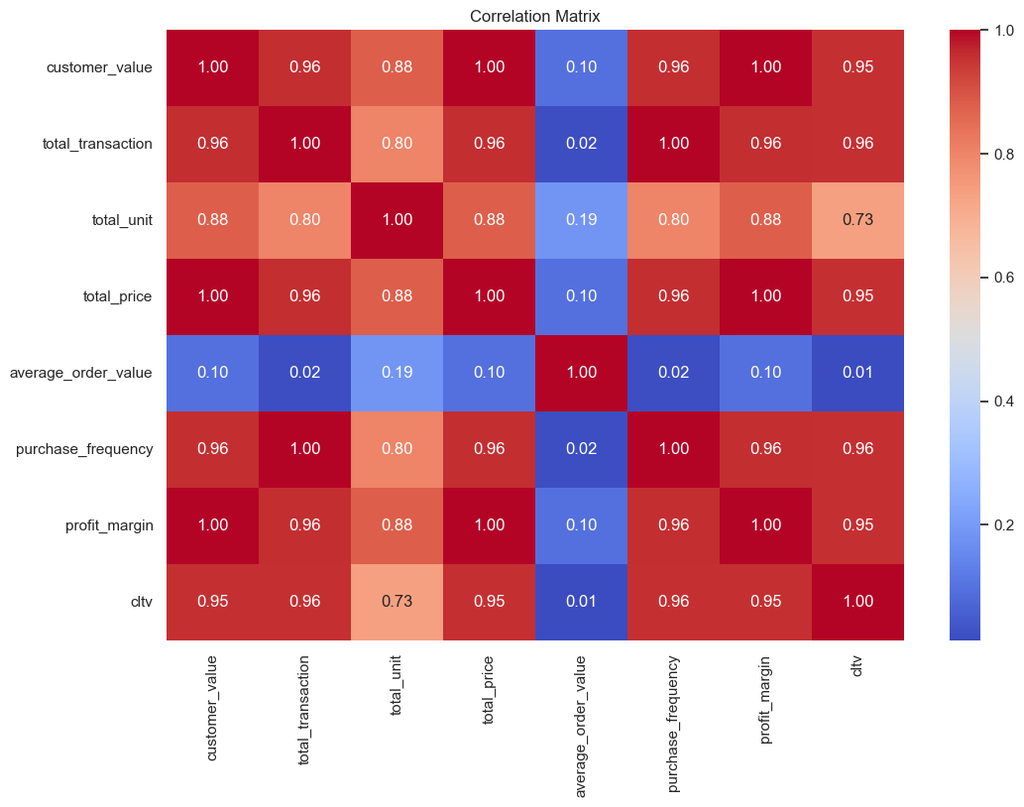

```python
# Graph showing correlation between various factors affecting CLTV

plt.figure(figsize=(12, 8))
correlation_matrix = cltv[['customer_value', 'total_transaction', 'total_unit', 'total_price', 'average_order_value', 'purchase_frequency', 'profit_margin', 'cltv']].corr()
sns.heatmap(correlation_matrix, annot=True, cmap='coolwarm', fmt='.2f')
plt.title('Correlation Matrix')
plt.show()
```

## 14. Creating Train-Test sets

```python
# Assuming 'CLTV' is the target variable you want to predict
X = cltv.drop(['customer id', 'cltv'], axis=1)
y = cltv['cltv']

# Split the data into training and test sets
X_train, X_test, y_train, y_test = train_test_split(X, y, test_size=0.2, random_state=42)
```

```python
scaler = StandardScaler()
X_train = scaler.fit_transform(X_train)
X_test = scaler.transform(X_test)
```

#### Linear Regression Model

Linear regression predicts a continuous outcome by modeling the relationship between a dependent variable and one or more independent variables.

```python
# Train the model
lr_model = LinearRegression()
lr_model.fit(X_train, y_train)

# Predict and evaluate
y_pred_lr = lr_model.predict(X_test)
mse_lr = mean_squared_error(y_test, y_pred_lr)
print(f'Linear Regression MSE: {mse_lr}')
```

```
Linear Regression MSE: 2460344354133.9146
```

#### Random Forest Regressor Model

RandomForestRegressor is an ensemble learning method that predicts a continuous outcome using multiple decision trees, improving accuracy and reducing overfitting.

```python
# Train the model
rf_model = RandomForestRegressor(n_estimators=100, random_state=42)
rf_model.fit(X_train, y_train)

# Predict and evaluate
y_pred_rf = rf_model.predict(X_test)
mse_rf = mean_squared_error(y_test, y_pred_rf)
print(f'Random Forest Regressor MSE: {mse_rf}')
```

```
Random Forest Regressor MSE: 11985669513.200487
```

#### SVR Model

Support Vector Regression (SVR) is a machine learning method that predicts continuous outcomes by finding the best-fit line within a margin of tolerance.

```python
# Train the model
svr_model = SVR(kernel='rbf')
svr_model.fit(X_train, y_train)

# Predict and evaluate
y_pred_svr = svr_model.predict(X_test)
mse_svr = mean_squared_error(y_test, y_pred_svr)
print(f'Support Vector Regressor MSE: {mse_svr}')
```

```
Support Vector Regressor MSE: 298679535578.0751
```

#### MLP Regressor

MLPRegressor is a neural network model that predicts continuous outcomes by learning complex patterns through multiple layers of interconnected nodes (neurons).

MLPRegressor can be applied in retail to predict Customer Lifetime Value (CLTV) by analyzing various customer-related features such as purchase frequency, average order value, and customer behavior patterns. By capturing complex relationships in the data, it helps retailers forecast the future value a customer will bring to the business, enabling more effective marketing, personalized promotions, and customer retention strategies.

```python
# Train the model
nn_model = MLPRegressor(hidden_layer_sizes=(50, 50), max_iter=500, random_state=42)
nn_model.fit(X_train, y_train)

# Predict and evaluate
y_pred_nn = nn_model.predict(X_test)
mse_nn = mean_squared_error(y_test, y_pred_nn)
print(f'Neural Network Regressor MSE: {mse_nn}')
```

```
Neural Network Regressor MSE: 182117357538.35764
```

```python
print(f'Linear Regression MSE: {mse_lr}')
print(f'Random Forest Regressor MSE: {mse_rf}')
print(f'Support Vector Regressor MSE: {mse_svr}')
print(f'Neural Network Regressor MSE: {mse_nn}')
```

```
Linear Regression MSE: 2460344354133.9146
Random Forest Regressor MSE: 11985669513.200487
Support Vector Regressor MSE: 298679535578.0751
Neural Network Regressor MSE: 182117357538.35764
```

- The Random Forest Regressor is the most effective model based on the Mean Squared Error (MSE) values provided. It has the lowest MSE of 11,985,669,513.20, indicating it makes the most accurate predictions compared to the other models.
- The purpose of extracting feature importances and visualizing them using the provided code is to understand which features contribute most to the predictive power of the Random Forest model.

```python
# Extract feature importances
importances = rf_model.feature_importances_

# Create a DataFrame for visualization
features = X.columns
feature_importance_df = pd.DataFrame({
    'Feature': features,
    'Importance': importances
}).sort_values(by='Importance', ascending=False)
```

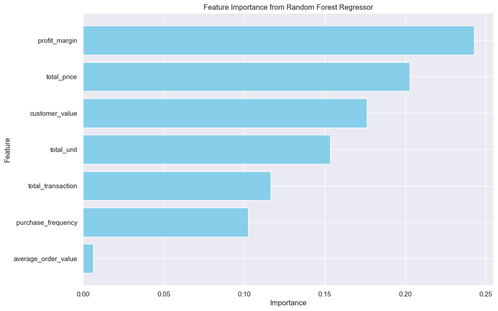

```python
# Plot feature importances
plt.figure(figsize=(12, 8))
plt.barh(feature_importance_df['Feature'], feature_importance_df['Importance'], color='skyblue')
plt.xlabel('Importance')
plt.ylabel('Feature')
plt.title('Feature Importance from Random Forest Regressor')
plt.gca().invert_yaxis()  # Invert y-axis to show the most important features at the top
```

```python
# Calculate Mean Absolute Error
mae_rf = mean_absolute_error(y_test, y_pred_rf)
print(f'Random Forest Regressor MAE: {mae_rf}')
```

```
Random Forest Regressor MAE: 5729.560806273545
```

- Prediction Accuracy: An MAE of 5729.56 suggests that the Random Forest Regressor has a reasonable level of prediction accuracy. The smaller the MAE, the closer the predicted values are to the actual values, indicating better model performance.
- Error Magnitude: The MAE provides a straightforward measure of the average error in the model’s predictions, without considering the direction of the errors (i.e., whether they are over- or under-predicted).

```python
# Calculate R-squared
r2_rf = r2_score(y_test, y_pred_rf)
print(f'Random Forest Regressor R²: {r2_rf}')
```

```
Random Forest Regressor R²: 0.9597641376684108
```

- Explained Variance: The R2R2 score, also known as the coefficient of determination, represents the proportion of variance in the target variable that is explained by the model. A score of 0.9598 means that approximately 95.98% of the variance in the target variable is explained by the Random Forest model. This is a very strong performance, suggesting that the model fits the data extremely well.
- Goodness of Fit: A high R2R2 score close to 1 indicates that the model's predictions are very close to the actual values, and the model is capturing most of the underlying patterns in the data.

## 15. RFM Analysis

#### RFM: Recency, Frequency, Monetary

One of the methods used in CRM Analytics is RFM Analysis. RFM is a combination of the initials of the terms Recency, Frequency and Monetary, each of which deals with a different characteristic of the customer.

#### RFM Metrics

##### Recency

Measures how long it has been since a customer's last interaction with the company. It is calculated by subtracting the date of the customer's last purchase from the analysis date (typically set close to the date of data collection for historical datasets). Customers who have shopped more recently are more likely to remain engaged with the brand. This metric also helps identify inactive customers who may benefit from targeted efforts to re-engage them.

##### Frequency

Represents the number of times a customer makes a purchase. By recognizing patterns in purchase frequency, businesses can anticipate when a customer might return and proactively remind them of their needs, improving retention.

##### Monetary Value

Indicates the total amount a customer has spent over their lifetime with the company. While this metric highlights high-spending customers, it's important to avoid neglecting those who spend less or are new, as they also contribute to long-term profitability.

```python
retail_dataset.info()
```

```
<class 'pandas.core.frame.DataFrame'>
Index: 964461 entries, 45228 to 541909
Data columns (total 14 columns):
 #   Column              Non-Null Count   Dtype
---  ------              --------------   -----
 0   invoice             964461 non-null  object
 1   stock_code          964461 non-null  string
 2   description         964461 non-null  object
 3   quantity            964461 non-null  int64
 4   invoice_date        964461 non-null  datetime64[ns]
 5   price               964461 non-null  float64
 6   customer id         964461 non-null  object
 7   country             964461 non-null  category
 8   amount              964461 non-null  float64
 9   country_encoded     964461 non-null  int64
 10  stock_code_encoded  964461 non-null  int64
 11  year                964461 non-null  int32
 12  month               964461 non-null  int32
 13  hour                964461 non-null  int32
dtypes: category(1), datetime64[ns](1), float64(2), int32(3), int64(3), object(3), string(1)
memory usage: 92.9+ MB
```

```python
retail_dataset.head(10)
```

|  | invoice | stock_code | description | quantity | invoice_date | price | customer id | country | amount | country_encoded | stock_code_encoded | year | month | hour |
| --- | --- | --- | --- | --- | --- | --- | --- | --- | --- | --- | --- | --- | --- | --- |
| 45228 | 493410 | TEST001 | This is a test product. | 5 | 2010-01-04 09:24:00 | 4.500000 | 12346.000000 | United Kingdom | 22.500000 | 40 | 4907 | 2010 | 1 | 9 |
| 45230 | 493412 | TEST001 | This is a test product. | 5 | 2010-01-04 09:53:00 | 4.500000 | 12346.000000 | United Kingdom | 22.500000 | 40 | 4907 | 2010 | 1 | 9 |
| 45231 | 493413 | 21724 | PANDA AND BUNNIES STICKER SHEET | 1 | 2010-01-04 09:54:00 | 0.850000 | Unavailable | United Kingdom | 0.850000 | 40 | 1048 | 2010 | 1 | 9 |
| 45232 | 493413 | 84578 | ELEPHANT TOY WITH BLUE T-SHIRT | 1 | 2010-01-04 09:54:00 | 3.750000 | Unavailable | United Kingdom | 3.750000 | 40 | 3725 | 2010 | 1 | 9 |
| 45233 | 493413 | 21723 | ALPHABET HEARTS STICKER SHEET | 1 | 2010-01-04 09:54:00 | 0.850000 | Unavailable | United Kingdom | 0.850000 | 40 | 1047 | 2010 | 1 | 9 |
| 45234 | 493414 | 21844 | RETRO SPOT MUG | 36 | 2010-01-04 10:28:00 | 2.550000 | 14590.000000 | United Kingdom | 91.800000 | 40 | 1149 | 2010 | 1 | 10 |
| 45235 | 493414 | 21533 | RETRO SPOT LARGE MILK JUG | 12 | 2010-01-04 10:28:00 | 4.250000 | 14590.000000 | United Kingdom | 51.000000 | 40 | 886 | 2010 | 1 | 10 |
| 45236 | 493414 | 37508 | NEW ENGLAND CERAMIC CAKE SERVER | 2 | 2010-01-04 10:28:00 | 2.550000 | 14590.000000 | United Kingdom | 5.100000 | 40 | 3040 | 2010 | 1 | 10 |
| 45237 | 493414 | 35001G | HAND OPEN SHAPE GOLD | 2 | 2010-01-04 10:28:00 | 4.250000 | 14590.000000 | United Kingdom | 8.500000 | 40 | 2801 | 2010 | 1 | 10 |
| 45238 | 493414 | 21527 | RETRO SPOT TRADITIONAL TEAPOT | 12 | 2010-01-04 10:28:00 | 6.950000 | 14590.000000 | United Kingdom | 83.400000 | 40 | 880 | 2010 | 1 | 10 |

```python
# Top 10 product sold
retail_dataset.groupby("description").agg({"quantity":"sum"}).sort_values("quantity", ascending = False).head(10)
```

| description | quantity |
| --- | --- |
| WORLD WAR 2 GLIDERS ASSTD DESIGNS | 103436 |
| WHITE HANGING HEART T-LIGHT HOLDER | 88252 |
| PAPER CRAFT , LITTLE BIRDIE | 80995 |
| MEDIUM CERAMIC TOP STORAGE JAR | 78033 |
| JUMBO BAG RED RETROSPOT | 77699 |
| ASSORTED COLOUR BIRD ORNAMENT | 75440 |
| BROCADE RING PURSE | 69568 |
| PACK OF 60 PINK PAISLEY CAKE CASES | 54866 |
| 60 TEATIME FAIRY CAKE CASES | 52206 |
| SMALL POPCORN HOLDER | 48561 |

```python
retail_dataset.describe().T
```

|  | count | mean | min | 25% | 50% | 75% | max | std |
| --- | --- | --- | --- | --- | --- | --- | --- | --- |
| quantity | 964461.000000 | 11.176904 | 1.000000 | 1.000000 | 4.000000 | 12.000000 | 80995.000000 | 130.825843 |
| invoice_date | 964461 | 2011-01-21 23:53:49.182517248 | 2010-01-04 09:24:00 | 2010-08-06 10:06:00 | 2011-01-05 11:41:00 | 2011-08-07 12:54:00 | 2011-12-09 12:50:00 | NaN |
| price | 964461.000000 | 4.064777 | 0.000000 | 1.250000 | 2.100000 | 4.130000 | 25111.090000 | 51.409487 |
| amount | 964461.000000 | 20.378377 | 0.001000 | 4.130000 | 10.080000 | 17.700000 | 168469.600000 | 209.965728 |
| country_encoded | 964461.000000 | 38.095580 | 0.000000 | 40.000000 | 40.000000 | 40.000000 | 42.000000 | 6.902242 |
| stock_code_encoded | 964461.000000 | 1923.847896 | 0.000000 | 1138.000000 | 1699.000000 | 2480.000000 | 4916.000000 | 1164.417141 |
| year | 964461.000000 | 2010.501719 | 2010.000000 | 2010.000000 | 2011.000000 | 2011.000000 | 2011.000000 | 0.499997 |
| month | 964461.000000 | 7.196450 | 1.000000 | 4.000000 | 8.000000 | 10.000000 | 12.000000 | 3.435886 |
| hour | 964461.000000 | 13.000370 | 6.000000 | 11.000000 | 13.000000 | 15.000000 | 20.000000 | 2.418431 |

```python
# We'll print the dates to get what is the before and closest purchase date to which we're evaluating
print("Farthest Purchase Date and Time : ", retail_dataset["invoice_date"].min())
print("Recent Purchase date and Time   : ", retail_dataset["invoice_date"].max())
```

```
Farthest Purchase Date and Time :  2010-01-04 09:24:00
Recent Purchase date and Time   :  2011-12-09 12:50:00
```

```python
collect_date = dt.datetime(2011, 12, 14)
```

```python
collect_date
```

```
datetime.datetime(2011, 12, 14, 0, 0)
```

##### So, now for RFM Analysis we'll create a seperate database that will contain the data of Recency, Frequency and Monetary Value

```python
retail_dataset.info()
```

```
<class 'pandas.core.frame.DataFrame'>
Index: 964461 entries, 45228 to 541909
Data columns (total 14 columns):
 #   Column              Non-Null Count   Dtype
---  ------              --------------   -----
 0   invoice             964461 non-null  object
 1   stock_code          964461 non-null  string
 2   description         964461 non-null  object
 3   quantity            964461 non-null  int64
 4   invoice_date        964461 non-null  datetime64[ns]
 5   price               964461 non-null  float64
 6   customer id         964461 non-null  object
 7   country             964461 non-null  category
 8   amount              964461 non-null  float64
 9   country_encoded     964461 non-null  int64
 10  stock_code_encoded  964461 non-null  int64
 11  year                964461 non-null  int32
 12  month               964461 non-null  int32
 13  hour                964461 non-null  int32
dtypes: category(1), datetime64[ns](1), float64(2), int32(3), int64(3), object(3), string(1)
memory usage: 92.9+ MB
```

```python
rfm = retail_dataset.groupby("customer id").agg({
    'invoice_date': lambda invoice_date: (collect_date - invoice_date.max()).days,
    'invoice': lambda invoice: invoice.nunique(),
    'amount': lambda TotalAmount: TotalAmount.sum()
})
```

```python
rfm.head(10)
```

| customer id | invoice_date | invoice | amount |
| --- | --- | --- | --- |
| 12346.0 | 329 | 7 | 77442.960000 |
| 12347.0 | 6 | 8 | 4921.530000 |
| 12348.0 | 79 | 5 | 2019.400000 |
| 12349.0 | 22 | 4 | 4428.690000 |
| 12350.0 | 314 | 1 | 334.400000 |
| 12351.0 | 379 | 1 | 300.930000 |
| 12352.0 | 40 | 10 | 2849.840000 |
| 12353.0 | 208 | 2 | 406.760000 |
| 12354.0 | 236 | 1 | 1079.400000 |
| 12355.0 | 218 | 2 | 947.610000 |

```python
rfm.head()
```

| customer id | invoice_date | invoice | amount |
| --- | --- | --- | --- |
| 12346.0 | 329 | 7 | 77442.960000 |
| 12347.0 | 6 | 8 | 4921.530000 |
| 12348.0 | 79 | 5 | 2019.400000 |
| 12349.0 | 22 | 4 | 4428.690000 |
| 12350.0 | 314 | 1 | 334.400000 |

```python
# Now we will rename the columns into Recency, Frequency, Monetary
rfm.columns = ["recency", "frequency", "monetary"]
rfm.head(10)
```

| customer id | recency | frequency | monetary |
| --- | --- | --- | --- |
| 12346.0 | 329 | 7 | 77442.960000 |
| 12347.0 | 6 | 8 | 4921.530000 |
| 12348.0 | 79 | 5 | 2019.400000 |
| 12349.0 | 22 | 4 | 4428.690000 |
| 12350.0 | 314 | 1 | 334.400000 |
| 12351.0 | 379 | 1 | 300.930000 |
| 12352.0 | 40 | 10 | 2849.840000 |
| 12353.0 | 208 | 2 | 406.760000 |
| 12354.0 | 236 | 1 | 1079.400000 |
| 12355.0 | 218 | 2 | 947.610000 |

```python
# Checking if our dataset has zero as value because we don't want zero and it will affect the modeling later on
zero = (rfm == 0).any(axis = 1).sum()
zero
```

```
0
```

#### RFM Score Calculation

```python
# Calculating the recency score
rfm['recency_score'] = pd.qcut(rfm["recency"], 5, labels = [5,4,3,2,1])

# Calculating the frequency score
rfm['frequency_score'] = pd.qcut(rfm["frequency"].rank(method="first"), 5, labels=[1,2,3,4,5])

# Calculating the monetary score
rfm["monetary_score"] = pd.qcut(rfm["monetary"], 5, labels = [1,2,3,4,5])

# Now we'll calculate the RF Score of the of the customers
rfm["rf_score"] = (rfm["recency_score"].astype(str) + rfm["frequency_score"].astype(str))

rfm.head(10)
```

| customer id | recency | frequency | monetary | recency_score | frequency_score | monetary_score | rf_score |
| --- | --- | --- | --- | --- | --- | --- | --- |
| 12346.0 | 329 | 7 | 77442.960000 | 2 | 4 | 5 | 24 |
| 12347.0 | 6 | 8 | 4921.530000 | 5 | 4 | 5 | 54 |
| 12348.0 | 79 | 5 | 2019.400000 | 3 | 4 | 4 | 34 |
| 12349.0 | 22 | 4 | 4428.690000 | 5 | 3 | 5 | 53 |
| 12350.0 | 314 | 1 | 334.400000 | 2 | 1 | 2 | 21 |
| 12351.0 | 379 | 1 | 300.930000 | 2 | 1 | 2 | 21 |
| 12352.0 | 40 | 10 | 2849.840000 | 4 | 5 | 4 | 45 |
| 12353.0 | 208 | 2 | 406.760000 | 2 | 2 | 2 | 22 |
| 12354.0 | 236 | 1 | 1079.400000 | 2 | 1 | 3 | 21 |
| 12355.0 | 218 | 2 | 947.610000 | 2 | 2 | 3 | 22 |

#### Customer Classification

- The customer segmentation approach shown in the image utilizes RFM (Recency, Frequency, Monetary) analysis to categorize customers based on their purchasing behavior
- This segmentation method is designed to provide a nuanced understanding of the customer base
- By categorizing customers this way, businesses can tailor their marketing and engagement strategies to each group's specific needs and potential value, optimizing resource allocation and improving customer relationships

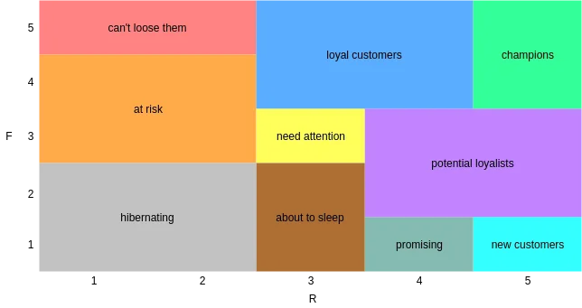

```python
Image(filename = r"/Users/prarthana/Downloads/dmwa6c18.png")
```

- **can't lose them** → A class of customers who used to shop very frequently but have not shopped for a long time and should not be lost.
- **at risk** → A class of customers who shop relatively frequently but have not shopped for a long time.
- **hibernating** → Customers who are literally asleep, both shopped infrequently and have not shopped for a long time.
- **about to sleep** → A class of customers who do not shop frequently and have not shopped for some time; they are heading towards sleep.
- **need attention** → This is the class of customers in the middle of the RF graph (33%), moving towards the risky group if not addressed.
- **new customers** → A class of customers who have not shopped frequently (maybe once) and have been shopping for a short period of time; they are considered new customers.
- **promising** → New customers are the aged version of new customers :) They are customers who have not shopped frequently and have shopped for a short period of time.
- **potential loyalists** → Customers who shop moderately often, and it has not been long since their last purchase.
- **loyal customers** → Customers who shop very often, and it has been a short time since their last purchase.
- **champions** → They are our champions, our crown jewels! Customers who shop very often and have made their last purchase within a very short period of time.

```python
champion_customer = rfm[rfm["rf_score"] == "55"].sort_values("monetary", ascending = False).head(10)
champion_customer
```

| customer id | recency | frequency | monetary | recency_score | frequency_score | monetary_score | rf_score |
| --- | --- | --- | --- | --- | --- | --- | --- |
| Unavailable | 4 | 2939 | 2962849.810000 | 5 | 5 | 5 | 55 |
| 18102.0 | 4 | 136 | 539981.300000 | 5 | 5 | 5 | 55 |
| 14646.0 | 5 | 146 | 513906.050000 | 5 | 5 | 5 | 55 |
| 14156.0 | 13 | 149 | 302386.400000 | 5 | 5 | 5 | 55 |
| 14911.0 | 5 | 389 | 284301.570000 | 5 | 5 | 5 | 55 |
| 17450.0 | 12 | 51 | 244784.250000 | 5 | 5 | 5 | 55 |
| 13694.0 | 7 | 131 | 175212.780000 | 5 | 5 | 5 | 55 |
| 17511.0 | 6 | 58 | 163765.060000 | 5 | 5 | 5 | 55 |
| 16684.0 | 8 | 52 | 144256.450000 | 5 | 5 | 5 | 55 |
| 15061.0 | 7 | 118 | 112076.480000 | 5 | 5 | 5 | 55 |

#### Categorizing Customer in Dataset

```python
rf_category_mapping = {
    r'[1-2][1-2]': 'hibernating',
    r'[1-2][3-4]': 'at_Risk',
    r'[1-2]5': 'cant_loose',
    r'3[1-2]': 'about_to_sleep',
    r'33': 'need_attention',
    r'[3-4][4-5]': 'loyal_customers',
    r'41': 'promising',
    r'51': 'new_customers',
    r'[4-5][2-3]': 'potential_loyalists',
    r'5[4-5]': 'champions'
}

# Creating a new column 'rf_category' based on 'rf_score'
rfm['rf_category'] = rfm['rf_score'].replace(rf_category_mapping, regex=True)

# Display the updated dataframe with both columns
rfm.head(20)
```

| customer id | recency | frequency | monetary | recency_score | frequency_score | monetary_score | rf_score | rf_category |
| --- | --- | --- | --- | --- | --- | --- | --- | --- |
| 12346.0 | 329 | 7 | 77442.960000 | 2 | 4 | 5 | 24 | at_Risk |
| 12347.0 | 6 | 8 | 4921.530000 | 5 | 4 | 5 | 54 | champions |
| 12348.0 | 79 | 5 | 2019.400000 | 3 | 4 | 4 | 34 | loyal_customers |
| 12349.0 | 22 | 4 | 4428.690000 | 5 | 3 | 5 | 53 | potential_loyalists |
| 12350.0 | 314 | 1 | 334.400000 | 2 | 1 | 2 | 21 | hibernating |
| 12351.0 | 379 | 1 | 300.930000 | 2 | 1 | 2 | 21 | hibernating |
| 12352.0 | 40 | 10 | 2849.840000 | 4 | 5 | 4 | 45 | loyal_customers |
| 12353.0 | 208 | 2 | 406.760000 | 2 | 2 | 2 | 22 | hibernating |
| 12354.0 | 236 | 1 | 1079.400000 | 2 | 1 | 3 | 21 | hibernating |
| 12355.0 | 218 | 2 | 947.610000 | 2 | 2 | 3 | 22 | hibernating |
| 12356.0 | 26 | 6 | 6371.730000 | 4 | 4 | 5 | 44 | loyal_customers |
| 12357.0 | 37 | 3 | 18287.660000 | 4 | 3 | 5 | 43 | potential_loyalists |
| 12358.0 | 5 | 4 | 2457.240000 | 5 | 3 | 4 | 53 | potential_loyalists |
| 12359.0 | 61 | 8 | 8034.500000 | 4 | 4 | 5 | 44 | loyal_customers |
| 12360.0 | 56 | 8 | 4252.890000 | 4 | 4 | 5 | 44 | loyal_customers |
| 12361.0 | 291 | 4 | 511.250000 | 2 | 3 | 2 | 23 | at_Risk |
| 12362.0 | 7 | 10 | 5226.230000 | 5 | 5 | 5 | 55 | champions |
| 12363.0 | 113 | 2 | 552.000000 | 3 | 2 | 2 | 32 | about_to_sleep |
| 12364.0 | 11 | 4 | 1313.100000 | 5 | 3 | 4 | 53 | potential_loyalists |
| 12365.0 | 295 | 2 | 641.380000 | 2 | 2 | 3 | 22 | hibernating |

```python
# Segments' Statistical Info
rfm[["rf_category", "recency", "frequency", "monetary"]].groupby("rf_category").agg(["mean", "count"])
```

| rf_category | recency mean | recency count | frequency mean | frequency count | monetary mean | monetary count |
| --- | --- | --- | --- | --- | --- | --- |
| about_to_sleep | 105.868633 | 373 | 1.353887 | 373 | 547.676469 | 373 |
| at_Risk | 359.801887 | 742 | 3.847709 | 742 | 1492.798154 | 742 |
| cant_loose | 323.695652 | 69 | 15.391304 | 69 | 6438.339159 | 69 |
| champions | 12.180851 | 846 | 22.055556 | 846 | 13670.681578 | 846 |
| hibernating | 444.730180 | 1501 | 1.248501 | 1501 | 428.960781 | 1501 |
| loyal_customers | 68.652135 | 1124 | 9.489324 | 1124 | 4039.830050 | 1124 |
| need_attention | 112.618321 | 262 | 3.083969 | 262 | 1096.016107 | 262 |
| new_customers | 14.438596 | 57 | 1.000000 | 57 | 355.102281 | 57 |
| potential_loyalists | 28.584986 | 706 | 2.549575 | 706 | 1139.793895 | 706 |
| promising | 41.772727 | 110 | 1.000000 | 110 | 325.798636 | 110 |

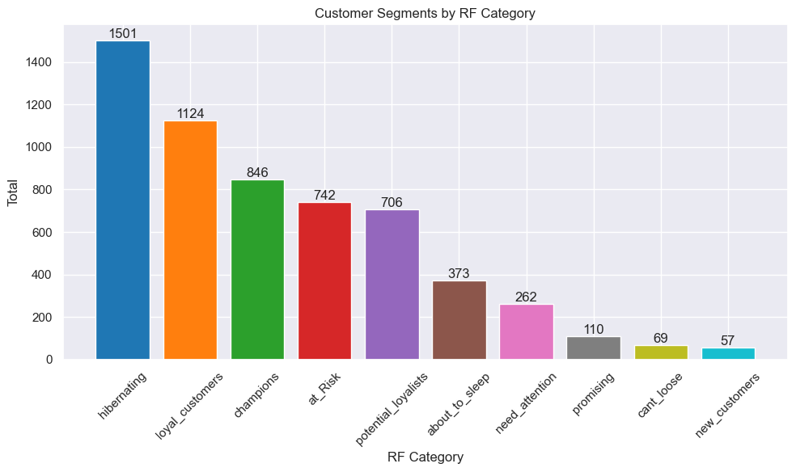

```python
# Count the occurrences of each category
category_counts = rfm['rf_category'].value_counts()

# Plotting the bar chart
plt.figure(figsize=(10, 6))
bars = plt.bar(category_counts.index, category_counts.values, color=plt.cm.tab10.colors)

# Adding the count labels on top of each bar
for bar in bars:
    yval = bar.get_height()
    plt.text(bar.get_x() + bar.get_width()/2, yval, int(yval), ha='center', va='bottom')

# Adding titles and labels
plt.title('Customer Segments by RF Category')
plt.xlabel('RF Category')
plt.ylabel('Total')
plt.xticks(rotation=45)
plt.tight_layout()  # Adjust layout to prevent clipping of tick-labels
plt.show()
```

Observations and findings:

1. "Hibernating" customers are the most numerous (1501), reinforcing the need for reactivation strategies.
2. "Loyal customers" (1124) and "champions" (846) form a significant base of valuable customers.
3. There's a substantial number of "at risk" (742) and "potential loyalists" (706) customers, presenting both challenges and opportunities.
4. The relatively low number of "new customers" (57) suggests a need for customer acquisition efforts.
5. The "can't loose" segment, while small (69), represents high-value customers who may need special attention to maintain their loyalty.

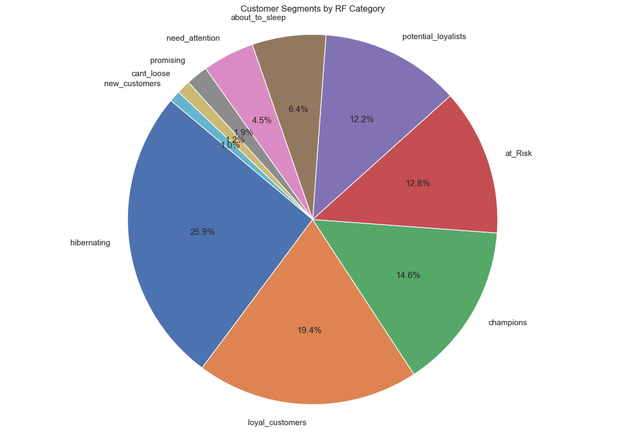

```python
# Plotting the pie chart
plt.figure(figsize=(15, 10))
plt.pie(category_counts, labels=category_counts.index, autopct='%1.1f%%', startangle=140)
plt.title('Customer Segments by RF Category')
plt.axis('equal')  # Equal aspect ratio ensures that pie chart is a circle.
plt.show()
```